# SSC2022-Competition

## Survey dataset data analysis

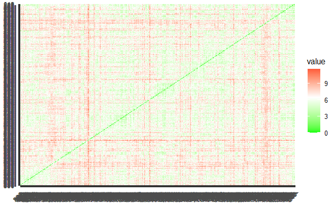

```r
distance <- get_dist(df_eval360_v20220321)
fviz_dist(distance, gradient = list(low = "green", mid = "white", high = "red"))
```

## Variable importance for Q23 in the evaluation dataset.

Since Q23 is the overall average we used it as our target variable.

```r
boruta_output <- Boruta(Q23~., data=na.omit(df_eval360_v20220321[,-24]), doTrace=0)
boruta_signif <- getSelectedAttributes(boruta_output, withTentative = TRUE)
print(boruta_signif)
```

```
[1] "Q12" "Q14" "Q19"
```

```r
# Do a tentative rough fix
roughFixMod <- TentativeRoughFix(boruta_output)
boruta_signif <- getSelectedAttributes(roughFixMod)
print(boruta_signif)
```

```
[1] "Q12"
```

```r
# Variable Importance Scores
imps <- attStats(roughFixMod)
imps2 = imps[imps$decision != 'Rejected', c('meanImp', 'decision')]
head(imps2[order(-imps2$meanImp), ])  # descending sort
```

|  | meanImp | decision |
| --- | --- | --- |
| Q12 | 8.956925 | Confirmed |

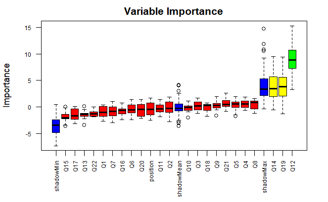

```r
# Plot variable importance
plot(boruta_output, cex.axis=.7, las=2, xlab="", main="Variable Importance")
```

# Random Forest

```r
set.seed(0)
model_rf <- ranger(Q23~., data=na.omit(df_eval360_v20220321[,-24]), mtry = 2, num.trees = 500, write.forest=TRUE, importance = "permutation")
```

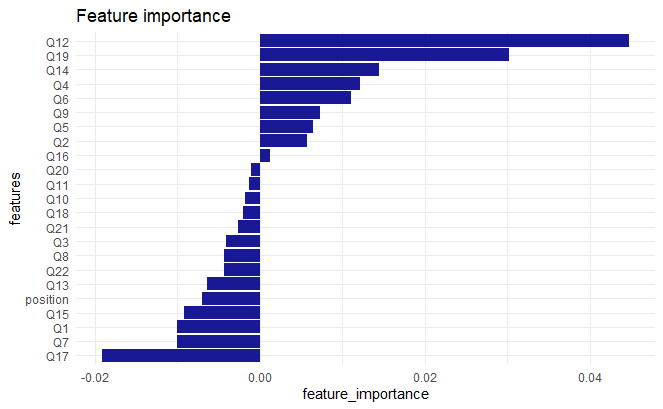

```r
p3<-data.frame(variables = names(importance(model_rf, method = "janitza")),           feature_importance = importance(model_rf, method = "janitza")) %>%
  ggplot(aes(x = feature_importance, y = reorder(variables, X = feature_importance))) +
    geom_bar(stat = "identity",  alpha=0.9, fill="darkblue") +
    labs(y = "features", title = "Feature importance") +
    theme_minimal(base_size = 10)
p3
```

# Variable Importance (RF) all dataset

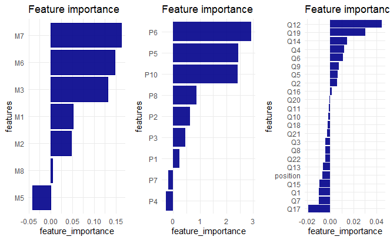

```r
multiplot(p1, p2, p3, cols=3)
```

# Adding new variables to evaluation dataset

First let add a variable (average) which will be the mean of Q1-Q22 evaluations. And then we will compare this average with the average score given at Q23. Variable (diff) will be the difference between average and Q23. If this diff is >= 0 then evaluation is reasonable. Otherwise , if diff<0 it means that based on Q1-Q22 they have over estimated the doctor and have given to him/her a score above the mean. In any case +- 1 is not “a big deal”.

```r
df_eval360_v20220321<-df_eval360_v20220321 %>% mutate(average=rowMeans(df_eval360_v20220321[,1:22],na.rm = T))
head(df_eval360_v20220321)
```

| Q1 | Q2 | Q3 | Q4 | Q5 | Q6 | Q7 | Q8 | Q9 | Q10 | Q11 | Q12 | Q13 | Q14 | Q15 | Q16 | Q17 | Q18 | Q19 | Q20 | Q21 | Q22 | Q23 | DocID | position | average |
| --- | --- | --- | --- | --- | --- | --- | --- | --- | --- | --- | --- | --- | --- | --- | --- | --- | --- | --- | --- | --- | --- | --- | --- | --- | --- |
| 4 | 5 | 5 | 5 | 4 | 5 | 2 | 5 | 4 | 3 | 5 | 4 | NA | 5 | 4 | 5 | 5 | 4 | 5 | 5 | NA | 4 | 3 | doc-09 | bedside | 4.400000 |
| 4 | 5 | 5 | 5 | 5 | 4 | 4 | 3 | 5 | 5 | 5 | 5 | NA | 4 | 5 | 5 | 3 | 3 | 3 | NA | 3 | 4 | 5 | doc-17 | bedside | 4.250000 |
| 4 | 4 | 5 | 3 | 5 | 4 | 3 | 4 | 5 | 5 | 5 | 4 | 1 | 4 | 4 | 5 | 5 | 2 | 4 | NA | 4 | 3 | 5 | doc-15 | bedside | 3.952381 |
| 5 | 5 | 5 | 5 | 4 | 4 | 3 | 4 | 5 | 5 | 5 | 5 | 2 | 4 | 4 | 5 | 5 | 5 | 4 | 5 | 4 | 5 | 5 | doc-01 | bedside | 4.454545 |
| 5 | 5 | 5 | 4 | 5 | 3 | 4 | 5 | 5 | 3 | 5 | 4 | 5 | 5 | 4 | 4 | 4 | 5 | 5 | 5 | 4 | 5 | 4 | doc-05 | non-bedside | 4.500000 |
| 5 | 4 | 4 | 5 | 3 | 5 | 4 | 5 | 5 | 4 | 4 | 5 | 5 | 3 | 5 | 5 | 5 | 5 | 5 | NA | 5 | 5 | 5 | doc-14 | non-bedside | 4.571429 |

```r
View(df_eval360_v20220321)
df_eval360_v20220321<-df_eval360_v20220321 %>% mutate(diff=df_eval360_v20220321$average-df_eval360_v20220321$Q23)
head(df_eval360_v20220321)
```

| Q1 | Q2 | Q3 | Q4 | Q5 | Q6 | Q7 | Q8 | Q9 | Q10 | Q11 | Q12 | Q13 | Q14 | Q15 | Q16 | Q17 | Q18 | Q19 | Q20 | Q21 | Q22 | Q23 | DocID | position | average | diff |
| --- | --- | --- | --- | --- | --- | --- | --- | --- | --- | --- | --- | --- | --- | --- | --- | --- | --- | --- | --- | --- | --- | --- | --- | --- | --- | --- |
| 4 | 5 | 5 | 5 | 4 | 5 | 2 | 5 | 4 | 3 | 5 | 4 | NA | 5 | 4 | 5 | 5 | 4 | 5 | 5 | NA | 4 | 3 | doc-09 | bedside | 4.400000 | 1.4000000 |
| 4 | 5 | 5 | 5 | 5 | 4 | 4 | 3 | 5 | 5 | 5 | 5 | NA | 4 | 5 | 5 | 3 | 3 | 3 | NA | 3 | 4 | 5 | doc-17 | bedside | 4.250000 | -0.7500000 |
| 4 | 4 | 5 | 3 | 5 | 4 | 3 | 4 | 5 | 5 | 5 | 4 | 1 | 4 | 4 | 5 | 5 | 2 | 4 | NA | 4 | 3 | 5 | doc-15 | bedside | 3.952381 | -1.0476190 |
| 5 | 5 | 5 | 5 | 4 | 4 | 3 | 4 | 5 | 5 | 5 | 5 | 2 | 4 | 4 | 5 | 5 | 5 | 4 | 5 | 4 | 5 | 5 | doc-01 | bedside | 4.454545 | -0.5454545 |
| 5 | 5 | 5 | 4 | 5 | 3 | 4 | 5 | 5 | 3 | 5 | 4 | 5 | 5 | 4 | 4 | 4 | 5 | 5 | 5 | 4 | 5 | 4 | doc-05 | non-bedside | 4.500000 | 0.5000000 |
| 5 | 4 | 4 | 5 | 3 | 5 | 4 | 5 | 5 | 4 | 4 | 5 | 5 | 3 | 5 | 5 | 5 | 5 | 5 | NA | 5 | 5 | 5 | doc-14 | non-bedside | 4.571429 | -0.4285714 |

```r
View(df_eval360_v20220321)
```

Look at the distrubution of average and Q23. It looks that there is no correlation between the Q23 and the Q1-Q22 evaluation.

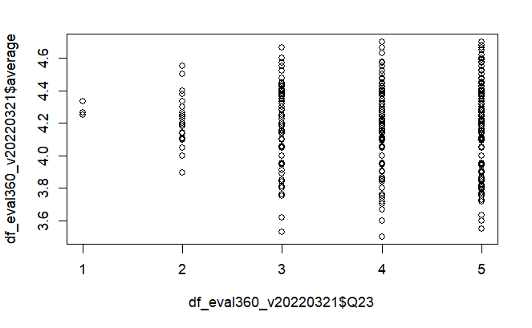

```r
plot(df_eval360_v20220321$Q23,df_eval360_v20220321$average)
```

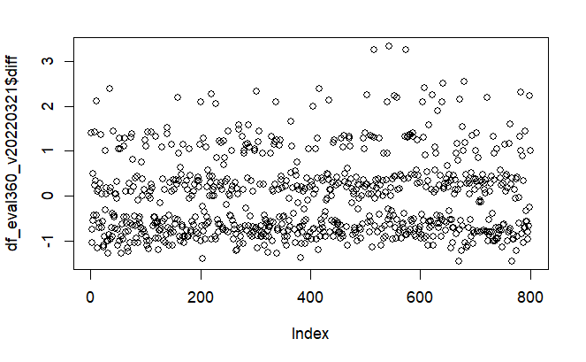

```r
plot(df_eval360_v20220321$diff)
```

Now lets create variables based on three main categories used for evaluation: Q1-Q9 related to Expert, professionalism etc. Q10-Q18 Communication and collaboration Q19-Q22 Management

Again here we will use the average . We are interested on doctors with evaluation performance: 4 (top half), 5 (among best).

```r
df_eval360_v20220321<-df_eval360_v20220321 %>% mutate(ave.Q1_Q9=rowMeans(df_eval360_v20220321[,1:9],na.rm = T))
head(df_eval360_v20220321)
```

| Q1 | Q2 | Q3 | Q4 | Q5 | Q6 | Q7 | Q8 | Q9 | Q10 | Q11 | Q12 | Q13 | Q14 | Q15 | Q16 | Q17 | Q18 | Q19 | Q20 | Q21 | Q22 | Q23 | DocID | position | average | diff | ave.Q1_Q9 |
| --- | --- | --- | --- | --- | --- | --- | --- | --- | --- | --- | --- | --- | --- | --- | --- | --- | --- | --- | --- | --- | --- | --- | --- | --- | --- | --- | --- |
| 4 | 5 | 5 | 5 | 4 | 5 | 2 | 5 | 4 | 3 | 5 | 4 | NA | 5 | 4 | 5 | 5 | 4 | 5 | 5 | NA | 4 | 3 | doc-09 | bedside | 4.400000 | 1.4000000 | 4.333333 |
| 4 | 5 | 5 | 5 | 5 | 4 | 4 | 3 | 5 | 5 | 5 | 5 | NA | 4 | 5 | 5 | 3 | 3 | 3 | NA | 3 | 4 | 5 | doc-17 | bedside | 4.250000 | -0.7500000 | 4.444444 |
| 4 | 4 | 5 | 3 | 5 | 4 | 3 | 4 | 5 | 5 | 5 | 4 | 1 | 4 | 4 | 5 | 5 | 2 | 4 | NA | 4 | 3 | 5 | doc-15 | bedside | 3.952381 | -1.0476190 | 4.111111 |
| 5 | 5 | 5 | 5 | 4 | 4 | 3 | 4 | 5 | 5 | 5 | 5 | 2 | 4 | 4 | 5 | 5 | 5 | 4 | 5 | 4 | 5 | 5 | doc-01 | bedside | 4.454545 | -0.5454545 | 4.444444 |
| 5 | 5 | 5 | 4 | 5 | 3 | 4 | 5 | 5 | 3 | 5 | 4 | 5 | 5 | 4 | 4 | 4 | 5 | 5 | 5 | 4 | 5 | 4 | doc-05 | non-bedside | 4.500000 | 0.5000000 | 4.555556 |
| 5 | 4 | 4 | 5 | 3 | 5 | 4 | 5 | 5 | 4 | 4 | 5 | 5 | 3 | 5 | 5 | 5 | 5 | 5 | NA | 5 | 5 | 5 | doc-14 | non-bedside | 4.571429 | -0.4285714 | 4.444444 |

```r
View(df_eval360_v20220321)

df_eval360_v20220321<-df_eval360_v20220321 %>% mutate(ave.Q10_Q18=rowMeans(df_eval360_v20220321[,10:18],na.rm = T))
head(df_eval360_v20220321)
```

| Q1 | Q2 | Q3 | Q4 | Q5 | Q6 | Q7 | Q8 | Q9 | Q10 | Q11 | Q12 | Q13 | Q14 | Q15 | Q16 | Q17 | Q18 | Q19 | Q20 | Q21 | Q22 | Q23 | DocID | position | average | diff | ave.Q1_Q9 | ave.Q10_Q18 |
| --- | --- | --- | --- | --- | --- | --- | --- | --- | --- | --- | --- | --- | --- | --- | --- | --- | --- | --- | --- | --- | --- | --- | --- | --- | --- | --- | --- | --- |
| 4 | 5 | 5 | 5 | 4 | 5 | 2 | 5 | 4 | 3 | 5 | 4 | NA | 5 | 4 | 5 | 5 | 4 | 5 | 5 | NA | 4 | 3 | doc-09 | bedside | 4.400000 | 1.4000000 | 4.333333 | 4.375000 |
| 4 | 5 | 5 | 5 | 5 | 4 | 4 | 3 | 5 | 5 | 5 | 5 | NA | 4 | 5 | 5 | 3 | 3 | 3 | NA | 3 | 4 | 5 | doc-17 | bedside | 4.250000 | -0.7500000 | 4.444444 | 4.375000 |
| 4 | 4 | 5 | 3 | 5 | 4 | 3 | 4 | 5 | 5 | 5 | 4 | 1 | 4 | 4 | 5 | 5 | 2 | 4 | NA | 4 | 3 | 5 | doc-15 | bedside | 3.952381 | -1.0476190 | 4.111111 | 3.888889 |
| 5 | 5 | 5 | 5 | 4 | 4 | 3 | 4 | 5 | 5 | 5 | 5 | 2 | 4 | 4 | 5 | 5 | 5 | 4 | 5 | 4 | 5 | 5 | doc-01 | bedside | 4.454545 | -0.5454545 | 4.444444 | 4.444444 |
| 5 | 5 | 5 | 4 | 5 | 3 | 4 | 5 | 5 | 3 | 5 | 4 | 5 | 5 | 4 | 4 | 4 | 5 | 5 | 5 | 4 | 5 | 4 | doc-05 | non-bedside | 4.500000 | 0.5000000 | 4.555556 | 4.333333 |
| 5 | 4 | 4 | 5 | 3 | 5 | 4 | 5 | 5 | 4 | 4 | 5 | 5 | 3 | 5 | 5 | 5 | 5 | 5 | NA | 5 | 5 | 5 | doc-14 | non-bedside | 4.571429 | -0.4285714 | 4.444444 | 4.555556 |

```r
View(df_eval360_v20220321)


df_eval360_v20220321<-df_eval360_v20220321 %>% mutate(ave.Q19_Q22=rowMeans(df_eval360_v20220321[,19:22],na.rm = T))
head(df_eval360_v20220321)
```

| Q1 | Q2 | Q3 | Q4 | Q5 | Q6 | Q7 | Q8 | Q9 | Q10 | Q11 | Q12 | Q13 | Q14 | Q15 | Q16 | Q17 | Q18 | Q19 | Q20 | Q21 | Q22 | Q23 | DocID | position | average | diff | ave.Q1_Q9 | ave.Q10_Q18 | ave.Q19_Q22 |
| --- | --- | --- | --- | --- | --- | --- | --- | --- | --- | --- | --- | --- | --- | --- | --- | --- | --- | --- | --- | --- | --- | --- | --- | --- | --- | --- | --- | --- | --- |
| 4 | 5 | 5 | 5 | 4 | 5 | 2 | 5 | 4 | 3 | 5 | 4 | NA | 5 | 4 | 5 | 5 | 4 | 5 | 5 | NA | 4 | 3 | doc-09 | bedside | 4.400000 | 1.4000000 | 4.333333 | 4.375000 | 4.666667 |
| 4 | 5 | 5 | 5 | 5 | 4 | 4 | 3 | 5 | 5 | 5 | 5 | NA | 4 | 5 | 5 | 3 | 3 | 3 | NA | 3 | 4 | 5 | doc-17 | bedside | 4.250000 | -0.7500000 | 4.444444 | 4.375000 | 3.333333 |
| 4 | 4 | 5 | 3 | 5 | 4 | 3 | 4 | 5 | 5 | 5 | 4 | 1 | 4 | 4 | 5 | 5 | 2 | 4 | NA | 4 | 3 | 5 | doc-15 | bedside | 3.952381 | -1.0476190 | 4.111111 | 3.888889 | 3.666667 |
| 5 | 5 | 5 | 5 | 4 | 4 | 3 | 4 | 5 | 5 | 5 | 5 | 2 | 4 | 4 | 5 | 5 | 5 | 4 | 5 | 4 | 5 | 5 | doc-01 | bedside | 4.454545 | -0.5454545 | 4.444444 | 4.444444 | 4.500000 |
| 5 | 5 | 5 | 4 | 5 | 3 | 4 | 5 | 5 | 3 | 5 | 4 | 5 | 5 | 4 | 4 | 4 | 5 | 5 | 5 | 4 | 5 | 4 | doc-05 | non-bedside | 4.500000 | 0.5000000 | 4.555556 | 4.333333 | 4.750000 |
| 5 | 4 | 4 | 5 | 3 | 5 | 4 | 5 | 5 | 4 | 4 | 5 | 5 | 3 | 5 | 5 | 5 | 5 | 5 | NA | 5 | 5 | 5 | doc-14 | non-bedside | 4.571429 | -0.4285714 | 4.444444 | 4.555556 | 5.000000 |

```r
View(df_eval360_v20220321)
```

Let us create some graphs understanding the performance of the doctors in evaluation dataset.

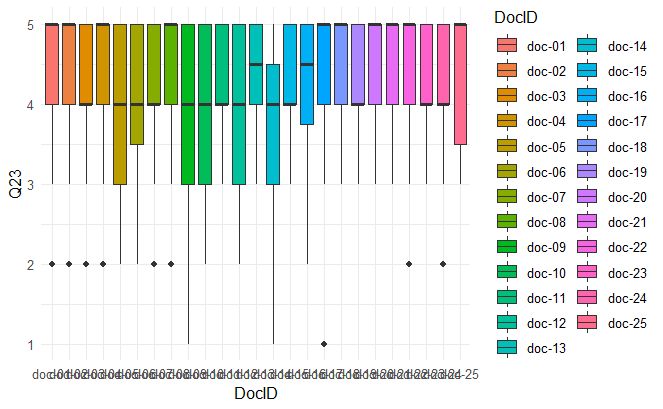

```r
ggplot(df_eval360_v20220321) +
  aes(x = DocID, y = Q23, fill = DocID) +
  geom_boxplot() +
  scale_fill_hue(direction = 1) +
  theme_minimal()
```

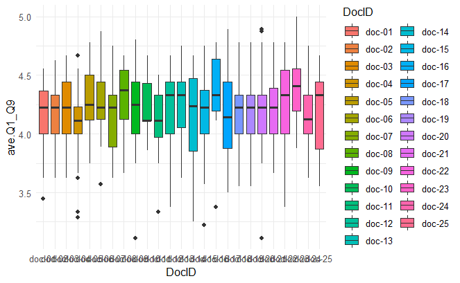

```r
ggplot(df_eval360_v20220321) +
  aes(x = DocID, y = ave.Q1_Q9, fill = DocID) +
  geom_boxplot() +
  scale_fill_hue(direction = 1) +
  theme_minimal()
```

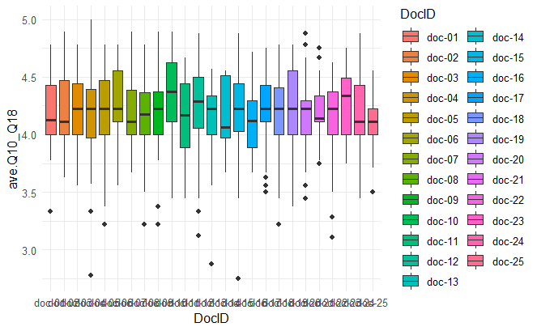

```r
ggplot(df_eval360_v20220321) +
  aes(x = DocID, y = ave.Q10_Q18, fill = DocID) +
  geom_boxplot() +
  scale_fill_hue(direction = 1) +
  theme_minimal()
```

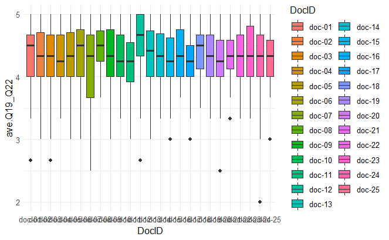

```r
ggplot(df_eval360_v20220321) +
  aes(x = DocID, y = ave.Q19_Q22, fill = DocID) +
  geom_boxplot() +
  scale_fill_hue(direction = 1) +
  theme_minimal()
```

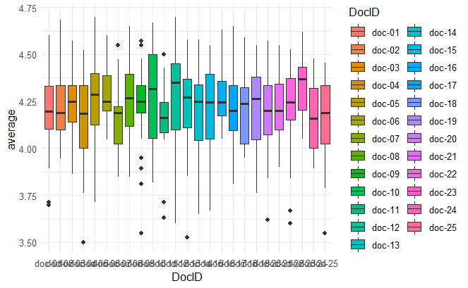

```r
ggplot(df_eval360_v20220321) +
  aes(x = DocID, y = average, fill = DocID) +
  geom_boxplot() +
  scale_fill_hue(direction = 1) +
  theme_minimal()
```

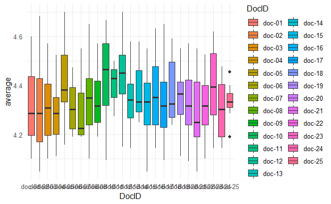

```r
df_eval360_v20220321 %>%
  filter(ave.Q1_Q9 >=4,ave.Q10_Q18 >=4, ave.Q19_Q22>=4)%>%
  ggplot() +
  aes(x = DocID, y = average, fill = DocID) +
  geom_boxplot() +
  scale_fill_hue(direction = 1) +
  theme_minimal()
```

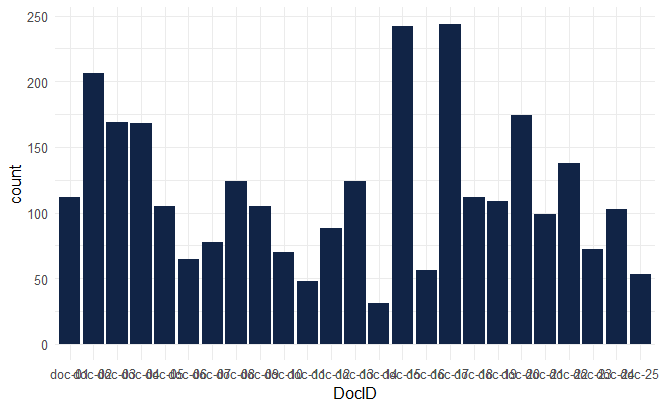

```r
df_eval360_v20220321 %>%
  filter(Q23>=4)%>%
ggplot() +
  aes(x = DocID, weight = Q23) +
  geom_bar(fill = "#112446") +
  theme_minimal()
```

## Measuring the physician performance (Top approach)

```r
df_eval360_v20220321<-df_eval360_v20220321 %>%
  mutate(Performance_1 = ifelse(ave.Q1_Q9>=3 & ave.Q10_Q18>=3 & ave.Q19_Q22>=3 & abs(diff)<=1,1,0))

head(df_eval360_v20220321)
```

| Q1 | Q2 | Q3 | Q4 | Q5 | Q6 | Q7 | Q8 | Q9 | Q10 | Q11 | Q12 | Q13 | Q14 | Q15 | Q16 | Q17 | Q18 | Q19 | Q20 | Q21 | Q22 | Q23 | DocID | position | average | diff | ave.Q1_Q9 | ave.Q10_Q18 | ave.Q19_Q22 | … |
| --- | --- | --- | --- | --- | --- | --- | --- | --- | --- | --- | --- | --- | --- | --- | --- | --- | --- | --- | --- | --- | --- | --- | --- | --- | --- | --- | --- | --- | --- | --- |
| 4 | 5 | 5 | 5 | 4 | 5 | 2 | 5 | 4 | 3 | 5 | 4 | NA | 5 | 4 | 5 | 5 | 4 | 5 | 5 | NA | 4 | 3 | doc-09 | bedside | 4.400000 | 1.4000000 | 4.333333 | 4.375000 | 4.666667 | … |
| 4 | 5 | 5 | 5 | 5 | 4 | 4 | 3 | 5 | 5 | 5 | 5 | NA | 4 | 5 | 5 | 3 | 3 | 3 | NA | 3 | 4 | 5 | doc-17 | bedside | 4.250000 | -0.7500000 | 4.444444 | 4.375000 | 3.333333 | … |
| 4 | 4 | 5 | 3 | 5 | 4 | 3 | 4 | 5 | 5 | 5 | 4 | 1 | 4 | 4 | 5 | 5 | 2 | 4 | NA | 4 | 3 | 5 | doc-15 | bedside | 3.952381 | -1.0476190 | 4.111111 | 3.888889 | 3.666667 | … |
| 5 | 5 | 5 | 5 | 4 | 4 | 3 | 4 | 5 | 5 | 5 | 5 | 2 | 4 | 4 | 5 | 5 | 5 | 4 | 5 | 4 | 5 | 5 | doc-01 | bedside | 4.454545 | -0.5454545 | 4.444444 | 4.444444 | 4.500000 | … |
| 5 | 5 | 5 | 4 | 5 | 3 | 4 | 5 | 5 | 3 | 5 | 4 | 5 | 5 | 4 | 4 | 4 | 5 | 5 | 5 | 4 | 5 | 4 | doc-05 | non-bedside | 4.500000 | 0.5000000 | 4.555556 | 4.333333 | 4.750000 | … |
| 5 | 4 | 4 | 5 | 3 | 5 | 4 | 5 | 5 | 4 | 4 | 5 | 5 | 3 | 5 | 5 | 5 | 5 | 5 | NA | 5 | 5 | 5 | doc-14 | non-bedside | 4.571429 | -0.4285714 | 4.444444 | 4.555556 | 5.000000 | … |

```r
View(df_eval360_v20220321)
```

If we want some descriptive statistics by group variable we can use:

```r
library(psych)
describeBy(df_eval360_v20220321, group=df_eval360_v20220321$Performance_1, fast=TRUE)
```

```
 Descriptive statistics by group
group: 0
```

|  | vars | n | mean | sd | min | max | range | se |
| --- | --- | --- | --- | --- | --- | --- | --- | --- |
| Q1 | 1 | 167 | 4.37 | 0.86 | 1.00 | 5.00 | 4.00 | 0.07 |
| Q2 | 2 | 165 | 4.37 | 0.77 | 2.00 | 5.00 | 3.00 | 0.06 |
| Q3 | 3 | 166 | 4.16 | 0.89 | 1.00 | 5.00 | 4.00 | 0.07 |
| Q4 | 4 | 171 | 4.17 | 0.98 | 1.00 | 5.00 | 4.00 | 0.08 |
| Q5 | 5 | 161 | 4.36 | 0.83 | 2.00 | 5.00 | 3.00 | 0.07 |
| Q6 | 6 | 169 | 3.99 | 1.04 | 2.00 | 5.00 | 3.00 | 0.08 |
| Q7 | 7 | 174 | 3.51 | 0.78 | 1.00 | 5.00 | 4.00 | 0.06 |
| Q8 | 8 | 170 | 4.03 | 1.14 | 1.00 | 5.00 | 4.00 | 0.09 |
| Q9 | 9 | 159 | 4.31 | 0.94 | 1.00 | 5.00 | 4.00 | 0.07 |
| Q10 | 10 | 172 | 4.05 | 1.18 | 1.00 | 5.00 | 4.00 | 0.09 |

[output cut: 21 more lines]

```
-----------------------------------------------------
group: 1
```

|  | vars | n | mean | sd | min | max | range | se |
| --- | --- | --- | --- | --- | --- | --- | --- | --- |
| Q1 | 1 | 584 | 4.43 | 0.79 | 1.00 | 5.00 | 4.00 | 0.03 |
| Q2 | 2 | 566 | 4.38 | 0.76 | 2.00 | 5.00 | 3.00 | 0.03 |
| Q3 | 3 | 564 | 4.33 | 0.78 | 1.00 | 5.00 | 4.00 | 0.03 |
| Q4 | 4 | 580 | 4.42 | 0.77 | 1.00 | 5.00 | 4.00 | 0.03 |
| Q5 | 5 | 557 | 4.41 | 0.80 | 1.00 | 5.00 | 4.00 | 0.03 |
| Q6 | 6 | 588 | 4.11 | 1.05 | 1.00 | 5.00 | 4.00 | 0.04 |
| Q7 | 7 | 600 | 3.52 | 0.82 | 1.00 | 5.00 | 4.00 | 0.03 |
| Q8 | 8 | 583 | 4.15 | 1.05 | 1.00 | 5.00 | 4.00 | 0.04 |
| Q9 | 9 | 555 | 4.38 | 0.81 | 2.00 | 5.00 | 3.00 | 0.03 |
| Q10 | 10 | 590 | 4.24 | 1.03 | 1.00 | 5.00 | 4.00 | 0.04 |

[output cut: 21 more lines]

```r
describeBy(df_eval360_v20220321, group=df_eval360_v20220321$DocID, fast=TRUE)
```

[output not shown]

[output cut: 145 more lines]

[output not shown]

```
 Descriptive statistics by group
group: doc-01
```

|  | vars | n | mean | sd | min | max | range | se |
| --- | --- | --- | --- | --- | --- | --- | --- | --- |
| Q1 | 1 | 29 | 4.34 | 0.86 | 2.00 | 5.00 | 3.00 | 0.16 |
| Q2 | 2 | 26 | 4.08 | 0.80 | 2.00 | 5.00 | 3.00 | 0.16 |
| Q3 | 3 | 29 | 4.55 | 0.74 | 3.00 | 5.00 | 2.00 | 0.14 |
| Q4 | 4 | 29 | 4.24 | 0.91 | 1.00 | 5.00 | 4.00 | 0.17 |
| Q5 | 5 | 25 | 4.08 | 0.81 | 2.00 | 5.00 | 3.00 | 0.16 |
| Q6 | 6 | 30 | 3.87 | 1.25 | 1.00 | 5.00 | 4.00 | 0.23 |
| Q7 | 7 | 30 | 3.47 | 0.90 | 1.00 | 5.00 | 4.00 | 0.16 |
| Q8 | 8 | 29 | 4.28 | 1.00 | 1.00 | 5.00 | 4.00 | 0.19 |
| Q9 | 9 | 30 | 4.33 | 0.96 | 2.00 | 5.00 | 3.00 | 0.18 |
| Q10 | 10 | 30 | 4.27 | 1.17 | 1.00 | 5.00 | 4.00 | 0.21 |

[output cut: 21 more lines]

```
-----------------------------------------------------
group: doc-02
```

|  | vars | n | mean | sd | min | max | range | se |
| --- | --- | --- | --- | --- | --- | --- | --- | --- |
| Q1 | 1 | 57 | 4.28 | 0.96 | 1.00 | 5.00 | 4.00 | 0.13 |
| Q2 | 2 | 55 | 4.49 | 0.74 | 2.00 | 5.00 | 3.00 | 0.10 |
| Q3 | 3 | 56 | 4.18 | 0.81 | 2.00 | 5.00 | 3.00 | 0.11 |
| Q4 | 4 | 58 | 4.26 | 1.00 | 1.00 | 5.00 | 4.00 | 0.13 |
| Q5 | 5 | 54 | 4.43 | 0.77 | 2.00 | 5.00 | 3.00 | 0.10 |
| Q6 | 6 | 59 | 4.03 | 1.02 | 1.00 | 5.00 | 4.00 | 0.13 |
| Q7 | 7 | 59 | 3.44 | 0.93 | 1.00 | 5.00 | 4.00 | 0.12 |
| Q8 | 8 | 56 | 4.27 | 1.09 | 1.00 | 5.00 | 4.00 | 0.15 |
| Q9 | 9 | 54 | 4.19 | 0.87 | 2.00 | 5.00 | 3.00 | 0.12 |
| Q10 | 10 | 57 | 4.21 | 1.16 | 1.00 | 5.00 | 4.00 | 0.15 |

[output cut: 21 more lines]

```
-----------------------------------------------------
group: doc-03
```

|  | vars | n | mean | sd | min | max | range | se |
| --- | --- | --- | --- | --- | --- | --- | --- | --- |
| Q1 | 1 | 48 | 4.33 | 0.91 | 1.00 | 5.00 | 4.00 | 0.13 |
| Q2 | 2 | 42 | 4.48 | 0.63 | 3.00 | 5.00 | 2.00 | 0.10 |
| Q3 | 3 | 46 | 4.30 | 0.79 | 3.00 | 5.00 | 2.00 | 0.12 |
| Q4 | 4 | 47 | 4.30 | 0.93 | 2.00 | 5.00 | 3.00 | 0.14 |
| Q5 | 5 | 42 | 4.48 | 0.74 | 3.00 | 5.00 | 2.00 | 0.11 |
| Q6 | 6 | 48 | 4.04 | 1.11 | 2.00 | 5.00 | 3.00 | 0.16 |
| Q7 | 7 | 48 | 3.54 | 0.71 | 1.00 | 4.00 | 3.00 | 0.10 |
| Q8 | 8 | 47 | 3.96 | 1.27 | 1.00 | 5.00 | 4.00 | 0.18 |
| Q9 | 9 | 44 | 4.50 | 0.73 | 2.00 | 5.00 | 3.00 | 0.11 |
| Q10 | 10 | 48 | 4.44 | 0.87 | 2.00 | 5.00 | 3.00 | 0.13 |

[output cut: 21 more lines]

```
-----------------------------------------------------
group: doc-04
```

|  | vars | n | mean | sd | min | max | range | se |
| --- | --- | --- | --- | --- | --- | --- | --- | --- |
| Q1 | 1 | 46 | 4.39 | 0.86 | 1.00 | 5.00 | 4.00 | 0.13 |
| Q2 | 2 | 47 | 4.34 | 0.79 | 2.00 | 5.00 | 3.00 | 0.11 |
| Q3 | 3 | 45 | 3.87 | 0.89 | 1.00 | 5.00 | 4.00 | 0.13 |
| Q4 | 4 | 48 | 4.33 | 0.75 | 3.00 | 5.00 | 2.00 | 0.11 |
| Q5 | 5 | 46 | 4.50 | 0.81 | 1.00 | 5.00 | 4.00 | 0.12 |
| Q6 | 6 | 45 | 3.93 | 1.01 | 2.00 | 5.00 | 3.00 | 0.15 |
| Q7 | 7 | 48 | 3.44 | 0.85 | 2.00 | 5.00 | 3.00 | 0.12 |
| Q8 | 8 | 48 | 3.83 | 1.19 | 1.00 | 5.00 | 4.00 | 0.17 |
| Q9 | 9 | 44 | 4.39 | 0.81 | 3.00 | 5.00 | 2.00 | 0.12 |
| Q10 | 10 | 47 | 4.23 | 1.18 | 1.00 | 5.00 | 4.00 | 0.17 |

[output cut: 21 more lines]

```
-----------------------------------------------------
group: doc-05
```

|  | vars | n | mean | sd | min | max | range | se |
| --- | --- | --- | --- | --- | --- | --- | --- | --- |
| Q1 | 1 | 33 | 4.48 | 0.76 | 2.00 | 5.00 | 3.00 | 0.13 |
| Q2 | 2 | 34 | 4.41 | 0.70 | 2.00 | 5.00 | 3.00 | 0.12 |
| Q3 | 3 | 32 | 4.50 | 0.62 | 3.00 | 5.00 | 2.00 | 0.11 |
| Q4 | 4 | 35 | 4.51 | 0.78 | 2.00 | 5.00 | 3.00 | 0.13 |
| Q5 | 5 | 34 | 4.15 | 0.78 | 2.00 | 5.00 | 3.00 | 0.13 |
| Q6 | 6 | 34 | 4.18 | 1.03 | 2.00 | 5.00 | 3.00 | 0.18 |
| Q7 | 7 | 35 | 3.71 | 0.71 | 2.00 | 5.00 | 3.00 | 0.12 |
| Q8 | 8 | 35 | 4.17 | 1.01 | 2.00 | 5.00 | 3.00 | 0.17 |
| Q9 | 9 | 31 | 4.58 | 0.67 | 3.00 | 5.00 | 2.00 | 0.12 |
| Q10 | 10 | 34 | 4.24 | 1.13 | 1.00 | 5.00 | 4.00 | 0.19 |

[output cut: 21 more lines]

```
-----------------------------------------------------
group: doc-06
```

|  | vars | n | mean | sd | min | max | range | se |
| --- | --- | --- | --- | --- | --- | --- | --- | --- |
| Q1 | 1 | 19 | 4.53 | 0.77 | 2.00 | 5.00 | 3.00 | 0.18 |
| Q2 | 2 | 19 | 4.16 | 0.90 | 2.00 | 5.00 | 3.00 | 0.21 |
| Q3 | 3 | 20 | 4.35 | 0.75 | 3.00 | 5.00 | 2.00 | 0.17 |
| Q4 | 4 | 21 | 4.33 | 0.66 | 3.00 | 5.00 | 2.00 | 0.14 |
| Q5 | 5 | 20 | 4.50 | 0.95 | 2.00 | 5.00 | 3.00 | 0.21 |
| Q6 | 6 | 21 | 4.05 | 1.02 | 2.00 | 5.00 | 3.00 | 0.22 |
| Q7 | 7 | 21 | 3.86 | 0.65 | 3.00 | 5.00 | 2.00 | 0.14 |
| Q8 | 8 | 20 | 4.10 | 1.02 | 2.00 | 5.00 | 3.00 | 0.23 |
| Q9 | 9 | 21 | 4.38 | 0.86 | 3.00 | 5.00 | 2.00 | 0.19 |
| Q10 | 10 | 21 | 3.86 | 0.91 | 2.00 | 5.00 | 3.00 | 0.20 |

[output cut: 21 more lines]

```
-----------------------------------------------------
group: doc-07
```

|  | vars | n | mean | sd | min | max | range | se |
| --- | --- | --- | --- | --- | --- | --- | --- | --- |
| Q1 | 1 | 23 | 4.30 | 0.97 | 2.00 | 5.00 | 3.00 | 0.20 |
| Q2 | 2 | 21 | 4.00 | 1.00 | 2.00 | 5.00 | 3.00 | 0.22 |
| Q3 | 3 | 23 | 4.43 | 0.73 | 3.00 | 5.00 | 2.00 | 0.15 |
| Q4 | 4 | 22 | 4.41 | 0.80 | 3.00 | 5.00 | 2.00 | 0.17 |
| Q5 | 5 | 22 | 4.09 | 0.87 | 2.00 | 5.00 | 3.00 | 0.19 |
| Q6 | 6 | 22 | 4.05 | 0.90 | 2.00 | 5.00 | 3.00 | 0.19 |
| Q7 | 7 | 23 | 3.48 | 0.79 | 2.00 | 5.00 | 3.00 | 0.16 |
| Q8 | 8 | 21 | 4.62 | 0.50 | 4.00 | 5.00 | 1.00 | 0.11 |
| Q9 | 9 | 22 | 4.09 | 0.97 | 2.00 | 5.00 | 3.00 | 0.21 |
| Q10 | 10 | 23 | 4.35 | 0.83 | 2.00 | 5.00 | 3.00 | 0.17 |

[output cut: 21 more lines]

```
-----------------------------------------------------
group: doc-08
```

|  | vars | n | mean | sd | min | max | range | se |
| --- | --- | --- | --- | --- | --- | --- | --- | --- |
| Q1 | 1 | 30 | 4.50 | 0.73 | 2.00 | 5.00 | 3.00 | 0.13 |
| Q2 | 2 | 27 | 4.33 | 0.78 | 3.00 | 5.00 | 2.00 | 0.15 |
| Q3 | 3 | 27 | 4.11 | 0.85 | 2.00 | 5.00 | 3.00 | 0.16 |
| Q4 | 4 | 29 | 4.62 | 0.56 | 3.00 | 5.00 | 2.00 | 0.10 |
| Q5 | 5 | 26 | 4.65 | 0.69 | 2.00 | 5.00 | 3.00 | 0.14 |
| Q6 | 6 | 30 | 4.23 | 1.01 | 2.00 | 5.00 | 3.00 | 0.18 |
| Q7 | 7 | 30 | 3.43 | 0.82 | 1.00 | 5.00 | 4.00 | 0.15 |
| Q8 | 8 | 29 | 4.28 | 0.80 | 2.00 | 5.00 | 3.00 | 0.15 |
| Q9 | 9 | 28 | 4.57 | 0.79 | 2.00 | 5.00 | 3.00 | 0.15 |
| Q10 | 10 | 30 | 4.13 | 1.25 | 1.00 | 5.00 | 4.00 | 0.23 |

[output cut: 21 more lines]

```
-----------------------------------------------------
group: doc-09
```

|  | vars | n | mean | sd | min | max | range | se |
| --- | --- | --- | --- | --- | --- | --- | --- | --- |
| Q1 | 1 | 31 | 4.39 | 0.72 | 2.00 | 5.00 | 3.00 | 0.13 |
| Q2 | 2 | 30 | 4.63 | 0.49 | 4.00 | 5.00 | 1.00 | 0.09 |
| Q3 | 3 | 30 | 4.20 | 1.00 | 2.00 | 5.00 | 3.00 | 0.18 |
| Q4 | 4 | 33 | 4.21 | 0.99 | 2.00 | 5.00 | 3.00 | 0.17 |
| Q5 | 5 | 31 | 4.58 | 0.62 | 3.00 | 5.00 | 2.00 | 0.11 |
| Q6 | 6 | 32 | 4.22 | 0.79 | 3.00 | 5.00 | 2.00 | 0.14 |
| Q7 | 7 | 33 | 3.42 | 0.79 | 2.00 | 5.00 | 3.00 | 0.14 |
| Q8 | 8 | 30 | 4.07 | 1.08 | 2.00 | 5.00 | 3.00 | 0.20 |
| Q9 | 9 | 31 | 4.19 | 0.95 | 1.00 | 5.00 | 4.00 | 0.17 |
| Q10 | 10 | 32 | 4.19 | 1.09 | 1.00 | 5.00 | 4.00 | 0.19 |

[output cut: 21 more lines]

```
-----------------------------------------------------
group: doc-10
```

|  | vars | n | mean | sd | min | max | range | se |
| --- | --- | --- | --- | --- | --- | --- | --- | --- |
| Q1 | 1 | 20 | 4.70 | 0.47 | 4.00 | 5.00 | 1.00 | 0.11 |
| Q2 | 2 | 19 | 4.53 | 0.84 | 2.00 | 5.00 | 3.00 | 0.19 |
| Q3 | 3 | 19 | 4.26 | 0.87 | 3.00 | 5.00 | 2.00 | 0.20 |
| Q4 | 4 | 21 | 4.62 | 0.59 | 3.00 | 5.00 | 2.00 | 0.13 |
| Q5 | 5 | 21 | 4.33 | 1.06 | 1.00 | 5.00 | 4.00 | 0.23 |
| Q6 | 6 | 20 | 3.85 | 1.04 | 2.00 | 5.00 | 3.00 | 0.23 |
| Q7 | 7 | 21 | 3.67 | 0.66 | 2.00 | 4.00 | 2.00 | 0.14 |
| Q8 | 8 | 21 | 3.90 | 1.00 | 2.00 | 5.00 | 3.00 | 0.22 |
| Q9 | 9 | 18 | 4.22 | 0.94 | 2.00 | 5.00 | 3.00 | 0.22 |
| Q10 | 10 | 21 | 4.24 | 1.26 | 1.00 | 5.00 | 4.00 | 0.28 |

[output cut: 21 more lines]

```
-----------------------------------------------------
group: doc-11
```

|  | vars | n | mean | sd | min | max | range | se |
| --- | --- | --- | --- | --- | --- | --- | --- | --- |
| Q1 | 1 | 12 | 4.17 | 1.19 | 1.00 | 5.00 | 4.00 | 0.34 |
| Q2 | 2 | 12 | 4.42 | 0.67 | 3.00 | 5.00 | 2.00 | 0.19 |
| Q3 | 3 | 12 | 4.17 | 0.58 | 3.00 | 5.00 | 2.00 | 0.17 |
| Q4 | 4 | 12 | 4.42 | 0.79 | 3.00 | 5.00 | 2.00 | 0.23 |
| Q5 | 5 | 11 | 4.45 | 0.82 | 3.00 | 5.00 | 2.00 | 0.25 |
| Q6 | 6 | 11 | 3.45 | 1.37 | 1.00 | 5.00 | 4.00 | 0.41 |
| Q7 | 7 | 12 | 3.50 | 0.67 | 2.00 | 4.00 | 2.00 | 0.19 |
| Q8 | 8 | 12 | 3.67 | 1.07 | 2.00 | 5.00 | 3.00 | 0.31 |
| Q9 | 9 | 11 | 4.64 | 0.67 | 3.00 | 5.00 | 2.00 | 0.20 |
| Q10 | 10 | 11 | 4.00 | 1.00 | 2.00 | 5.00 | 3.00 | 0.30 |

[output cut: 21 more lines]

```
-----------------------------------------------------
group: doc-12
```

|  | vars | n | mean | sd | min | max | range | se |
| --- | --- | --- | --- | --- | --- | --- | --- | --- |
| Q1 | 1 | 27 | 4.63 | 0.84 | 1.00 | 5.00 | 4.00 | 0.16 |
| Q2 | 2 | 25 | 4.20 | 0.71 | 3.00 | 5.00 | 2.00 | 0.14 |
| Q3 | 3 | 26 | 4.38 | 0.80 | 3.00 | 5.00 | 2.00 | 0.16 |
| Q4 | 4 | 27 | 4.30 | 0.95 | 1.00 | 5.00 | 4.00 | 0.18 |
| Q5 | 5 | 25 | 4.56 | 0.65 | 3.00 | 5.00 | 2.00 | 0.13 |
| Q6 | 6 | 27 | 4.26 | 1.06 | 2.00 | 5.00 | 3.00 | 0.20 |
| Q7 | 7 | 27 | 3.48 | 0.80 | 2.00 | 5.00 | 3.00 | 0.15 |
| Q8 | 8 | 27 | 3.85 | 0.82 | 2.00 | 5.00 | 3.00 | 0.16 |
| Q9 | 9 | 24 | 4.62 | 0.58 | 3.00 | 5.00 | 2.00 | 0.12 |
| Q10 | 10 | 27 | 4.15 | 1.20 | 1.00 | 5.00 | 4.00 | 0.23 |

[output cut: 21 more lines]

```
-----------------------------------------------------
group: doc-13
```

|  | vars | n | mean | sd | min | max | range | se |
| --- | --- | --- | --- | --- | --- | --- | --- | --- |
| Q1 | 1 | 34 | 4.71 | 0.58 | 3.00 | 5.00 | 2.00 | 0.10 |
| Q2 | 2 | 32 | 4.19 | 0.82 | 2.00 | 5.00 | 3.00 | 0.15 |
| Q3 | 3 | 33 | 4.39 | 0.66 | 3.00 | 5.00 | 2.00 | 0.11 |
| Q4 | 4 | 32 | 4.47 | 0.76 | 2.00 | 5.00 | 3.00 | 0.13 |
| Q5 | 5 | 32 | 4.53 | 0.76 | 2.00 | 5.00 | 3.00 | 0.13 |
| Q6 | 6 | 31 | 3.94 | 1.09 | 2.00 | 5.00 | 3.00 | 0.20 |
| Q7 | 7 | 34 | 3.50 | 0.66 | 2.00 | 4.00 | 2.00 | 0.11 |
| Q8 | 8 | 33 | 4.33 | 1.05 | 1.00 | 5.00 | 4.00 | 0.18 |
| Q9 | 9 | 31 | 4.32 | 0.91 | 2.00 | 5.00 | 3.00 | 0.16 |
| Q10 | 10 | 32 | 4.38 | 1.04 | 1.00 | 5.00 | 4.00 | 0.18 |

[output cut: 21 more lines]

```
-----------------------------------------------------
group: doc-14
```

|  | vars | n | mean | sd | min | max | range | se |
| --- | --- | --- | --- | --- | --- | --- | --- | --- |
| Q1 | 1 | 12 | 4.00 | 1.04 | 2.00 | 5.00 | 3.00 | 0.30 |
| Q2 | 2 | 12 | 4.25 | 0.75 | 3.00 | 5.00 | 2.00 | 0.22 |
| Q3 | 3 | 9 | 4.44 | 0.88 | 3.00 | 5.00 | 2.00 | 0.29 |
| Q4 | 4 | 12 | 4.25 | 0.75 | 3.00 | 5.00 | 2.00 | 0.22 |
| Q5 | 5 | 12 | 4.00 | 1.21 | 1.00 | 5.00 | 4.00 | 0.35 |
| Q6 | 6 | 12 | 4.33 | 0.89 | 2.00 | 5.00 | 3.00 | 0.26 |
| Q7 | 7 | 12 | 3.17 | 1.03 | 1.00 | 4.00 | 3.00 | 0.30 |
| Q8 | 8 | 12 | 4.25 | 0.87 | 3.00 | 5.00 | 2.00 | 0.25 |
| Q9 | 9 | 11 | 4.64 | 0.81 | 3.00 | 5.00 | 2.00 | 0.24 |
| Q10 | 10 | 12 | 4.08 | 1.16 | 1.00 | 5.00 | 4.00 | 0.34 |

[output cut: 21 more lines]

```
-----------------------------------------------------
group: doc-15
```

|  | vars | n | mean | sd | min | max | range | se |
| --- | --- | --- | --- | --- | --- | --- | --- | --- |
| Q1 | 1 | 60 | 4.43 | 0.74 | 2.00 | 5.00 | 3.00 | 0.10 |
| Q2 | 2 | 59 | 4.37 | 0.72 | 3.00 | 5.00 | 2.00 | 0.09 |
| Q3 | 3 | 59 | 4.32 | 0.88 | 1.00 | 5.00 | 4.00 | 0.11 |
| Q4 | 4 | 60 | 4.23 | 0.79 | 2.00 | 5.00 | 3.00 | 0.10 |
| Q5 | 5 | 56 | 4.43 | 0.76 | 2.00 | 5.00 | 3.00 | 0.10 |
| Q6 | 6 | 58 | 4.07 | 1.02 | 1.00 | 5.00 | 4.00 | 0.13 |
| Q7 | 7 | 62 | 3.60 | 0.64 | 2.00 | 5.00 | 3.00 | 0.08 |
| Q8 | 8 | 61 | 4.11 | 0.93 | 1.00 | 5.00 | 4.00 | 0.12 |
| Q9 | 9 | 57 | 4.23 | 0.85 | 1.00 | 5.00 | 4.00 | 0.11 |
| Q10 | 10 | 62 | 4.35 | 0.85 | 2.00 | 5.00 | 3.00 | 0.11 |

[output cut: 21 more lines]

```
-----------------------------------------------------
group: doc-16
```

|  | vars | n | mean | sd | min | max | range | se |
| --- | --- | --- | --- | --- | --- | --- | --- | --- |
| Q1 | 1 | 16 | 3.81 | 1.17 | 2.00 | 5.00 | 3.00 | 0.29 |
| Q2 | 2 | 15 | 4.33 | 0.72 | 3.00 | 5.00 | 2.00 | 0.19 |
| Q3 | 3 | 14 | 4.64 | 0.50 | 4.00 | 5.00 | 1.00 | 0.13 |
| Q4 | 4 | 16 | 4.31 | 0.95 | 2.00 | 5.00 | 3.00 | 0.24 |
| Q5 | 5 | 16 | 4.31 | 1.08 | 1.00 | 5.00 | 4.00 | 0.27 |
| Q6 | 6 | 16 | 4.50 | 0.73 | 3.00 | 5.00 | 2.00 | 0.18 |
| Q7 | 7 | 16 | 3.75 | 0.68 | 2.00 | 5.00 | 3.00 | 0.17 |
| Q8 | 8 | 15 | 4.80 | 0.41 | 4.00 | 5.00 | 1.00 | 0.11 |
| Q9 | 9 | 16 | 4.75 | 0.58 | 3.00 | 5.00 | 2.00 | 0.14 |
| Q10 | 10 | 15 | 4.20 | 1.21 | 1.00 | 5.00 | 4.00 | 0.31 |

[output cut: 21 more lines]

```
-----------------------------------------------------
group: doc-17
```

|  | vars | n | mean | sd | min | max | range | se |
| --- | --- | --- | --- | --- | --- | --- | --- | --- |
| Q1 | 1 | 64 | 4.33 | 0.80 | 2.00 | 5.00 | 3.00 | 0.10 |
| Q2 | 2 | 63 | 4.51 | 0.67 | 3.00 | 5.00 | 2.00 | 0.08 |
| Q3 | 3 | 63 | 4.24 | 0.91 | 1.00 | 5.00 | 4.00 | 0.11 |
| Q4 | 4 | 65 | 4.46 | 0.73 | 2.00 | 5.00 | 3.00 | 0.09 |
| Q5 | 5 | 58 | 4.38 | 0.85 | 2.00 | 5.00 | 3.00 | 0.11 |
| Q6 | 6 | 64 | 3.88 | 1.16 | 1.00 | 5.00 | 4.00 | 0.15 |
| Q7 | 7 | 65 | 3.48 | 0.90 | 1.00 | 5.00 | 4.00 | 0.11 |
| Q8 | 8 | 65 | 3.92 | 1.25 | 1.00 | 5.00 | 4.00 | 0.16 |
| Q9 | 9 | 61 | 4.46 | 0.79 | 3.00 | 5.00 | 2.00 | 0.10 |
| Q10 | 10 | 63 | 4.29 | 0.94 | 2.00 | 5.00 | 3.00 | 0.12 |

[output cut: 21 more lines]

```
-----------------------------------------------------
group: doc-18
```

|  | vars | n | mean | sd | min | max | range | se |
| --- | --- | --- | --- | --- | --- | --- | --- | --- |
| Q1 | 1 | 25 | 4.32 | 0.69 | 3.00 | 5.00 | 2.00 | 0.14 |
| Q2 | 2 | 27 | 4.19 | 0.96 | 2.00 | 5.00 | 3.00 | 0.19 |
| Q3 | 3 | 26 | 4.31 | 0.84 | 3.00 | 5.00 | 2.00 | 0.16 |
| Q4 | 4 | 26 | 4.38 | 0.94 | 2.00 | 5.00 | 3.00 | 0.18 |
| Q5 | 5 | 27 | 4.52 | 0.80 | 2.00 | 5.00 | 3.00 | 0.15 |
| Q6 | 6 | 27 | 4.11 | 1.09 | 1.00 | 5.00 | 4.00 | 0.21 |
| Q7 | 7 | 27 | 3.48 | 0.98 | 1.00 | 4.00 | 3.00 | 0.19 |
| Q8 | 8 | 26 | 4.42 | 0.86 | 2.00 | 5.00 | 3.00 | 0.17 |
| Q9 | 9 | 24 | 3.88 | 0.99 | 2.00 | 5.00 | 3.00 | 0.20 |
| Q10 | 10 | 27 | 4.33 | 0.96 | 2.00 | 5.00 | 3.00 | 0.18 |

[output cut: 21 more lines]

```
-----------------------------------------------------
group: doc-19
```

|  | vars | n | mean | sd | min | max | range | se |
| --- | --- | --- | --- | --- | --- | --- | --- | --- |
| Q1 | 1 | 29 | 4.48 | 0.51 | 4.00 | 5.00 | 1.00 | 0.09 |
| Q2 | 2 | 28 | 4.36 | 0.78 | 2.00 | 5.00 | 3.00 | 0.15 |
| Q3 | 3 | 23 | 4.30 | 0.76 | 3.00 | 5.00 | 2.00 | 0.16 |
| Q4 | 4 | 28 | 4.29 | 0.94 | 1.00 | 5.00 | 4.00 | 0.18 |
| Q5 | 5 | 28 | 4.43 | 0.88 | 2.00 | 5.00 | 3.00 | 0.17 |
| Q6 | 6 | 29 | 4.38 | 0.90 | 2.00 | 5.00 | 3.00 | 0.17 |
| Q7 | 7 | 29 | 3.41 | 0.78 | 2.00 | 4.00 | 2.00 | 0.14 |
| Q8 | 8 | 28 | 3.96 | 1.26 | 2.00 | 5.00 | 3.00 | 0.24 |
| Q9 | 9 | 25 | 4.12 | 1.05 | 2.00 | 5.00 | 3.00 | 0.21 |
| Q10 | 10 | 29 | 4.17 | 1.00 | 2.00 | 5.00 | 3.00 | 0.19 |

[output cut: 21 more lines]

```
-----------------------------------------------------
group: doc-20
```

|  | vars | n | mean | sd | min | max | range | se |
| --- | --- | --- | --- | --- | --- | --- | --- | --- |
| Q1 | 1 | 42 | 4.64 | 0.66 | 2.00 | 5.00 | 3.00 | 0.10 |
| Q2 | 2 | 41 | 4.39 | 0.86 | 2.00 | 5.00 | 3.00 | 0.13 |
| Q3 | 3 | 41 | 4.12 | 0.81 | 2.00 | 5.00 | 3.00 | 0.13 |
| Q4 | 4 | 41 | 4.22 | 0.96 | 2.00 | 5.00 | 3.00 | 0.15 |
| Q5 | 5 | 41 | 4.51 | 0.60 | 3.00 | 5.00 | 2.00 | 0.09 |
| Q6 | 6 | 42 | 4.07 | 1.31 | 1.00 | 5.00 | 4.00 | 0.20 |
| Q7 | 7 | 43 | 3.63 | 0.72 | 2.00 | 5.00 | 3.00 | 0.11 |
| Q8 | 8 | 43 | 3.88 | 1.16 | 1.00 | 5.00 | 4.00 | 0.18 |
| Q9 | 9 | 39 | 4.59 | 0.75 | 2.00 | 5.00 | 3.00 | 0.12 |
| Q10 | 10 | 43 | 4.16 | 1.07 | 2.00 | 5.00 | 3.00 | 0.16 |

[output cut: 21 more lines]

```
-----------------------------------------------------
group: doc-21
```

|  | vars | n | mean | sd | min | max | range | se |
| --- | --- | --- | --- | --- | --- | --- | --- | --- |
| Q1 | 1 | 26 | 4.42 | 0.86 | 2.00 | 5.00 | 3.00 | 0.17 |
| Q2 | 2 | 26 | 4.35 | 0.63 | 3.00 | 5.00 | 2.00 | 0.12 |
| Q3 | 3 | 26 | 4.23 | 0.82 | 3.00 | 5.00 | 2.00 | 0.16 |
| Q4 | 4 | 27 | 4.30 | 0.87 | 2.00 | 5.00 | 3.00 | 0.17 |
| Q5 | 5 | 26 | 4.31 | 0.68 | 3.00 | 5.00 | 2.00 | 0.13 |
| Q6 | 6 | 27 | 3.89 | 0.89 | 2.00 | 5.00 | 3.00 | 0.17 |
| Q7 | 7 | 27 | 3.63 | 0.49 | 3.00 | 4.00 | 1.00 | 0.09 |
| Q8 | 8 | 25 | 4.28 | 1.06 | 1.00 | 5.00 | 4.00 | 0.21 |
| Q9 | 9 | 26 | 4.58 | 0.64 | 3.00 | 5.00 | 2.00 | 0.13 |
| Q10 | 10 | 27 | 3.85 | 1.38 | 1.00 | 5.00 | 4.00 | 0.27 |

[output cut: 21 more lines]

```
-----------------------------------------------------
group: doc-22
```

|  | vars | n | mean | sd | min | max | range | se |
| --- | --- | --- | --- | --- | --- | --- | --- | --- |
| Q1 | 1 | 32 | 4.56 | 0.67 | 3.00 | 5.00 | 2.00 | 0.12 |
| Q2 | 2 | 33 | 4.48 | 0.71 | 3.00 | 5.00 | 2.00 | 0.12 |
| Q3 | 3 | 32 | 4.44 | 0.72 | 3.00 | 5.00 | 2.00 | 0.13 |
| Q4 | 4 | 33 | 4.55 | 0.62 | 3.00 | 5.00 | 2.00 | 0.11 |
| Q5 | 5 | 32 | 4.34 | 0.83 | 3.00 | 5.00 | 2.00 | 0.15 |
| Q6 | 6 | 34 | 4.24 | 0.92 | 2.00 | 5.00 | 3.00 | 0.16 |
| Q7 | 7 | 34 | 3.44 | 0.89 | 2.00 | 5.00 | 3.00 | 0.15 |
| Q8 | 8 | 34 | 4.00 | 1.35 | 1.00 | 5.00 | 4.00 | 0.23 |
| Q9 | 9 | 30 | 4.40 | 0.72 | 3.00 | 5.00 | 2.00 | 0.13 |
| Q10 | 10 | 33 | 3.79 | 1.19 | 1.00 | 5.00 | 4.00 | 0.21 |

[output cut: 21 more lines]

```
-----------------------------------------------------
group: doc-23
```

|  | vars | n | mean | sd | min | max | range | se |
| --- | --- | --- | --- | --- | --- | --- | --- | --- |
| Q1 | 1 | 19 | 4.68 | 0.58 | 3.00 | 5.00 | 2.00 | 0.13 |
| Q2 | 2 | 20 | 4.55 | 0.83 | 3.00 | 5.00 | 2.00 | 0.18 |
| Q3 | 3 | 19 | 4.47 | 0.61 | 3.00 | 5.00 | 2.00 | 0.14 |
| Q4 | 4 | 16 | 4.31 | 0.95 | 2.00 | 5.00 | 3.00 | 0.24 |
| Q5 | 5 | 20 | 4.60 | 0.68 | 3.00 | 5.00 | 2.00 | 0.15 |
| Q6 | 6 | 20 | 4.30 | 1.08 | 2.00 | 5.00 | 3.00 | 0.24 |
| Q7 | 7 | 20 | 3.60 | 0.94 | 1.00 | 5.00 | 4.00 | 0.21 |
| Q8 | 8 | 20 | 4.60 | 0.68 | 3.00 | 5.00 | 2.00 | 0.15 |
| Q9 | 9 | 18 | 4.44 | 0.62 | 3.00 | 5.00 | 2.00 | 0.15 |
| Q10 | 10 | 19 | 4.21 | 0.98 | 2.00 | 5.00 | 3.00 | 0.22 |

[output cut: 21 more lines]

```
-----------------------------------------------------
group: doc-24
```

|  | vars | n | mean | sd | min | max | range | se |
| --- | --- | --- | --- | --- | --- | --- | --- | --- |
| Q1 | 1 | 28 | 4.43 | 0.74 | 3.00 | 5.00 | 2.00 | 0.14 |
| Q2 | 2 | 28 | 4.25 | 0.89 | 2.00 | 5.00 | 3.00 | 0.17 |
| Q3 | 3 | 28 | 4.32 | 0.86 | 2.00 | 5.00 | 3.00 | 0.16 |
| Q4 | 4 | 25 | 4.36 | 0.76 | 3.00 | 5.00 | 2.00 | 0.15 |
| Q5 | 5 | 24 | 3.83 | 0.96 | 2.00 | 5.00 | 3.00 | 0.20 |
| Q6 | 6 | 29 | 4.31 | 0.93 | 2.00 | 5.00 | 3.00 | 0.17 |
| Q7 | 7 | 29 | 3.55 | 0.91 | 1.00 | 5.00 | 4.00 | 0.17 |
| Q8 | 8 | 27 | 4.26 | 1.13 | 1.00 | 5.00 | 4.00 | 0.22 |
| Q9 | 9 | 27 | 4.00 | 0.96 | 2.00 | 5.00 | 3.00 | 0.18 |
| Q10 | 10 | 29 | 3.86 | 1.06 | 2.00 | 5.00 | 3.00 | 0.20 |

[output cut: 21 more lines]

```
-----------------------------------------------------
group: doc-25
```

|  | vars | n | mean | sd | min | max | range | se |
| --- | --- | --- | --- | --- | --- | --- | --- | --- |
| Q1 | 1 | 15 | 4.33 | 0.72 | 3.00 | 5.00 | 2.00 | 0.19 |
| Q2 | 2 | 15 | 4.27 | 0.96 | 3.00 | 5.00 | 2.00 | 0.25 |
| Q3 | 3 | 15 | 4.00 | 0.93 | 3.00 | 5.00 | 2.00 | 0.24 |
| Q4 | 4 | 14 | 4.50 | 0.76 | 3.00 | 5.00 | 2.00 | 0.20 |
| Q5 | 5 | 14 | 4.29 | 0.73 | 3.00 | 5.00 | 2.00 | 0.19 |
| Q6 | 6 | 15 | 3.93 | 1.28 | 1.00 | 5.00 | 4.00 | 0.33 |
| Q7 | 7 | 15 | 3.53 | 1.06 | 1.00 | 5.00 | 4.00 | 0.27 |
| Q8 | 8 | 14 | 4.21 | 0.89 | 3.00 | 5.00 | 2.00 | 0.24 |
| Q9 | 9 | 15 | 4.60 | 0.74 | 3.00 | 5.00 | 2.00 | 0.19 |
| Q10 | 10 | 15 | 4.13 | 0.99 | 2.00 | 5.00 | 3.00 | 0.26 |

[output cut: 21 more lines]

Performance evaluation of doctors from survey, we are looking at those physicians where the performance is greater than or equal to a given percentage. We remind that we are using the “top physicians” approach here.

```r
# for performance measure 1
library(dplyr)
Performance_survey<-df_eval360_v20220321 %>%
  group_by(DocID) %>%
  summarize(Good=sum(Performance_1==1,na.rm = T),Not_Good=sum(Performance_1==0,na.rm=T))

Performance_survey
```

| DocID | Good | Not_Good |
| --- | --- | --- |
| doc-01 | 20 | 8 |
| doc-02 | 44 | 14 |
| doc-03 | 37 | 9 |
| doc-04 | 30 | 16 |
| doc-05 | 22 | 12 |
| doc-06 | 14 | 5 |
| doc-07 | 17 | 4 |
| doc-08 | 25 | 5 |
| doc-09 | 22 | 11 |
| doc-10 | 14 | 7 |

[output cut: 15 more lines]

```r
Percentage_performance<-Performance_survey %>%
  mutate(Percentage_Good=round(100*Performance_survey$Good/(Performance_survey$Good+Performance_survey$Not_Good),0))
Percentage_performance # based on survey scores
```

| DocID | Good | Not_Good | Percentage_Good |
| --- | --- | --- | --- |
| doc-01 | 20 | 8 | 71 |
| doc-02 | 44 | 14 | 76 |
| doc-03 | 37 | 9 | 80 |
| doc-04 | 30 | 16 | 65 |
| doc-05 | 22 | 12 | 65 |
| doc-06 | 14 | 5 | 74 |
| doc-07 | 17 | 4 | 81 |
| doc-08 | 25 | 5 | 83 |
| doc-09 | 22 | 11 | 67 |
| doc-10 | 14 | 7 | 67 |

[output cut: 15 more lines]

```r
NA
```

Which doctors (DocID are printed out) have performance percentage based on survey greater than 70%, 75%, 80% and 85%?.

```r
# for performance measure 1
which(Percentage_performance$Percentage_Good>=70)
```

```
 [1]  1  2  3  6  7  8 11 12 13 14 15 16 17 18 19 20 21 22 23 24 25
```

```r
which(Percentage_performance$Percentage_Good>=75)
```

```
 [1]  2  3  7  8 11 13 15 16 17 18 19 20 21 22 23
```

```r
which(Percentage_performance$Percentage_Good>=80)
```

```
 [1]  3  7  8 11 15 17 18 19 20 21 22 23
```

```r
which(Percentage_performance$Percentage_Good>=85)
```

```
[1] 18 19 21 22
```

Another approach we can use for the performance measure is: consider separately Q23 and average of previous questions Q1-Q22

```r
df_eval360_v20220321<-df_eval360_v20220321 %>%
  mutate(Performance_2 = ifelse(ave.Q1_Q9>=3 & ave.Q10_Q18>=3 & ave.Q19_Q22>=3 & average>=4 & Q23>=4,1,0))

head(df_eval360_v20220321)
```

| Q1 | Q2 | Q3 | Q4 | Q5 | Q6 | Q7 | Q8 | Q9 | Q10 | Q11 | Q12 | Q13 | Q14 | Q15 | Q16 | Q17 | Q18 | Q19 | Q20 | Q21 | Q22 | Q23 | DocID | position | average | diff | ave.Q1_Q9 | ave.Q10_Q18 | ave.Q19_Q22 | … |
| --- | --- | --- | --- | --- | --- | --- | --- | --- | --- | --- | --- | --- | --- | --- | --- | --- | --- | --- | --- | --- | --- | --- | --- | --- | --- | --- | --- | --- | --- | --- |
| 4 | 5 | 5 | 5 | 4 | 5 | 2 | 5 | 4 | 3 | 5 | 4 | NA | 5 | 4 | 5 | 5 | 4 | 5 | 5 | NA | 4 | 3 | doc-09 | bedside | 4.400000 | 1.4000000 | 4.333333 | 4.375000 | 4.666667 | … |
| 4 | 5 | 5 | 5 | 5 | 4 | 4 | 3 | 5 | 5 | 5 | 5 | NA | 4 | 5 | 5 | 3 | 3 | 3 | NA | 3 | 4 | 5 | doc-17 | bedside | 4.250000 | -0.7500000 | 4.444444 | 4.375000 | 3.333333 | … |
| 4 | 4 | 5 | 3 | 5 | 4 | 3 | 4 | 5 | 5 | 5 | 4 | 1 | 4 | 4 | 5 | 5 | 2 | 4 | NA | 4 | 3 | 5 | doc-15 | bedside | 3.952381 | -1.0476190 | 4.111111 | 3.888889 | 3.666667 | … |
| 5 | 5 | 5 | 5 | 4 | 4 | 3 | 4 | 5 | 5 | 5 | 5 | 2 | 4 | 4 | 5 | 5 | 5 | 4 | 5 | 4 | 5 | 5 | doc-01 | bedside | 4.454545 | -0.5454545 | 4.444444 | 4.444444 | 4.500000 | … |
| 5 | 5 | 5 | 4 | 5 | 3 | 4 | 5 | 5 | 3 | 5 | 4 | 5 | 5 | 4 | 4 | 4 | 5 | 5 | 5 | 4 | 5 | 4 | doc-05 | non-bedside | 4.500000 | 0.5000000 | 4.555556 | 4.333333 | 4.750000 | … |
| 5 | 4 | 4 | 5 | 3 | 5 | 4 | 5 | 5 | 4 | 4 | 5 | 5 | 3 | 5 | 5 | 5 | 5 | 5 | NA | 5 | 5 | 5 | doc-14 | non-bedside | 4.571429 | -0.4285714 | 4.444444 | 4.555556 | 5.000000 | … |

```r
#View(df_eval360_v20220321)
```

```r
# for performance measure 1
library(dplyr)
Performance_survey<-df_eval360_v20220321 %>%
  group_by(DocID) %>%
 dplyr::summarize(Good=sum(Performance_2==1,na.rm = T),Not_Good=sum(Performance_2==0,na.rm=T))

Performance_survey
```

| DocID | Good | Not_Good |
| --- | --- | --- |
| doc-01 | 19 | 9 |
| doc-02 | 41 | 17 |
| doc-03 | 35 | 11 |
| doc-04 | 26 | 20 |
| doc-05 | 19 | 15 |
| doc-06 | 14 | 5 |
| doc-07 | 16 | 5 |
| doc-08 | 24 | 6 |
| doc-09 | 20 | 13 |
| doc-10 | 13 | 8 |

[output cut: 15 more lines]

```r
Percentage_performance<-Performance_survey %>%
  mutate(Percentage_Good=round(100*Performance_survey$Good/(Performance_survey$Good+Performance_survey$Not_Good),0))
Percentage_performance # based on survey scores
```

| DocID | Good | Not_Good | Percentage_Good |
| --- | --- | --- | --- |
| doc-01 | 19 | 9 | 68 |
| doc-02 | 41 | 17 | 71 |
| doc-03 | 35 | 11 | 76 |
| doc-04 | 26 | 20 | 57 |
| doc-05 | 19 | 15 | 56 |
| doc-06 | 14 | 5 | 74 |
| doc-07 | 16 | 5 | 76 |
| doc-08 | 24 | 6 | 80 |
| doc-09 | 20 | 13 | 61 |
| doc-10 | 13 | 8 | 62 |

[output cut: 15 more lines]

```r
# for performance measure 2
which(Percentage_performance$Percentage_Good>=70)
```

```
 [1]  2  3  6  7  8 11 13 15 16 17 18 19 20 21 22 23
```

```r
which(Percentage_performance$Percentage_Good>=75)
```

```
 [1]  3  7  8 11 15 16 17 18 19 20 22 23
```

```r
which(Percentage_performance$Percentage_Good>=77)
```

```
[1]  8 17 18 20 22 23
```

```r
which(Percentage_performance$Percentage_Good>=76)
```

```
[1]  3  7  8 17 18 20 22 23
```

```r
which(Percentage_performance$Percentage_Good>=80)
```

```
[1]  8 23
```

```r
which(Percentage_performance$Percentage_Good>=85)
```

```
integer(0)
```

# Physician dataset

Now we will work with doctor dataframe. we will add available Performance based on M4 and M5.

```r
i=which(df_doctors_v20220321$M5>=2) # which doctors have M5 greater than or equal to 2
i
```

```
 [1]  1  2  3  4  6  7  8  9 10 11 12 13 14 15 16 18 19 20 21 22 23 24
[23] 25
```

```r
fivenum(df_doctors_v20220321$M4) # observe the min, max and quartiles to decide on the level of M4 to consider for top doctors
```

```
[1] 2.316098 3.995118 4.483527 5.431024 6.936099
```

```r
i=which(df_doctors_v20220321$M4>=5) # which doctors have M4 greater then or equal to 5  (5 is close to 3rd quartile, so we are considering here almost 25% of physicians classified in top positions)
i
```

```
[1]  5  6  7 13 15 21 23 25
```

The performance (Remind: Top physician approach. We are interested in Top physicians.)

```r
df_doctors_v20220321<-df_doctors_v20220321 %>%
  mutate(Performance = ifelse(M4>=5 & M5>=2,1,0))

head(df_doctors_v20220321)
```

| DocID | M1 | M2 | M3 | M4 | M5 | M6 | M7 | M8 | M9 | Performance |
| --- | --- | --- | --- | --- | --- | --- | --- | --- | --- | --- |
| doc-01 | 2+ | leader_x | senior | 4.033301 | 2 | F | anesthesia | 50+ | NA | 0 |
| doc-02 | 2+ | leader_x | senior | 4.483527 | 2 | M | internal medicine | 50+ | MSc | 0 |
| doc-03 | 2+ | leader_x | junior | 4.256743 | 2 | F | pulmonary medicine | <50 | PhD | 0 |
| doc-04 | 1.0 | leader | junior | 4.175182 | 3 | F | emergency | <50 | NA | 0 |
| doc-05 | 1.0 | leader_x | junior | 5.610845 | 1 | M | internal medicine | 50+ | MMed | 0 |
| doc-06 | 2+ | leader | senior | 5.737756 | 2 | M | medicine | 50+ | MSc | 1 |

```r
View(df_doctors_v20220321)

which(df_doctors_v20220321$Performance==1)
```

```
[1]  6  7 13 15 21 23 25
```

```r
# [1]  6  7 13 15 21 23 25
```

```r
df_doctors_v20220321<-df_doctors_v20220321 %>%
  mutate(Performance = ifelse(M4>=5 & M5>=2,1,0))

head(df_doctors_v20220321)
```

| DocID | M1 | M2 | M3 | M4 | M5 | M6 | M7 | M8 | M9 | Performance |
| --- | --- | --- | --- | --- | --- | --- | --- | --- | --- | --- |
| doc-01 | 2+ | leader_x | senior | 4.033301 | 2 | F | anesthesia | 50+ | NA | 0 |
| doc-02 | 2+ | leader_x | senior | 4.483527 | 2 | M | internal medicine | 50+ | MSc | 0 |
| doc-03 | 2+ | leader_x | junior | 4.256743 | 2 | F | pulmonary medicine | <50 | PhD | 0 |
| doc-04 | 1.0 | leader | junior | 4.175182 | 3 | F | emergency | <50 | NA | 0 |
| doc-05 | 1.0 | leader_x | junior | 5.610845 | 1 | M | internal medicine | 50+ | MMed | 0 |
| doc-06 | 2+ | leader | senior | 5.737756 | 2 | M | medicine | 50+ | MSc | 1 |

```r
#View(df_doctors_v20220321)

which(df_doctors_v20220321$Performance==1)
```

```
[1]  6  7 13 15 21 23 25
```

```r
# [1]  6  7 13 15 21 23 25
```

# Performance from Patiend df

# Patient dataset

Some references: Sofa score reference: https://jamanetwork.com/journals/jama/fullarticle/194262 Sofa score greater tan 7 means mortality higher than 20%. https://clincalc.com/IcuMortality/SOFA.aspx

ICU stay length: https://www.ncbi.nlm.nih.gov/pmc/articles/PMC4792682/ ICU stay and financial cost: https://www.sciencedirect.com/science/article/pii/S2212109919306156

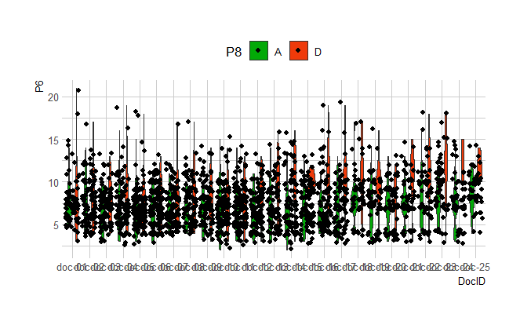

```r
df_patients_v20220321 %>%
  ggplot(.) +
  aes(x = DocID, y = P6, fill = P8) +
  geom_violin(adjust = 2L, scale = "area") +
  geom_jitter() +
  scale_fill_manual(values = c(A = "#02A907", D = "#EF3A0A")) +
  hrbrthemes::theme_ipsum_ps() +
  theme(legend.position = "top")
```

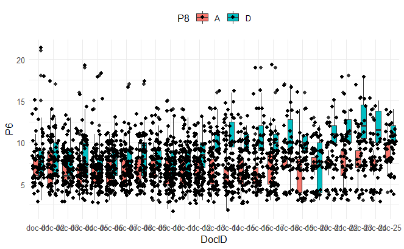

```r
df_patients_v20220321 %>%
  ggplot(.) +
  aes(x = DocID, y = P6, fill = P8) +
  geom_boxplot() +
  geom_jitter() +
  scale_fill_hue(direction = 1) +
  theme_minimal() +
  theme(legend.position = "top")
```

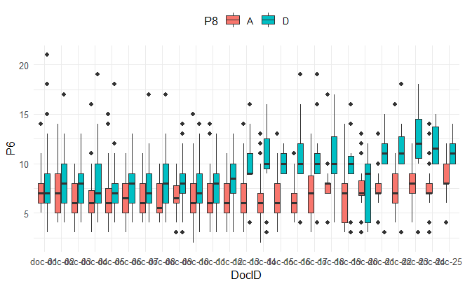

```r
df_patients_v20220321 %>%
  ggplot(.) +
  aes(x = DocID, y = P6, fill = P8) +
  geom_boxplot() +
    scale_fill_hue(direction = 1) +
  theme_minimal() +
  theme(legend.position = "top")
```

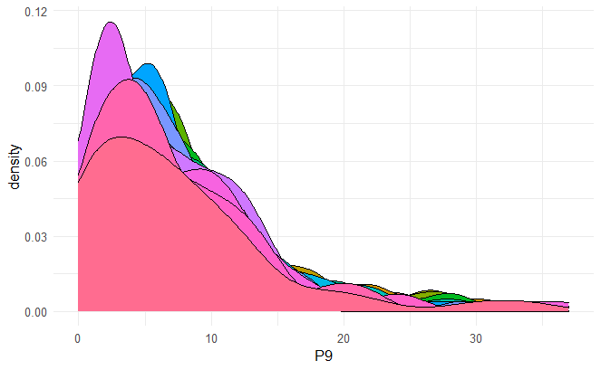

```r
p1<-df_patients_v20220321 %>%
  ggplot() +
  aes(x = P9, fill = DocID) +
  geom_density(adjust = 1L) +
  scale_fill_hue(direction = 1) +
  theme_minimal() +
  theme(legend.position = "none")
p1
```

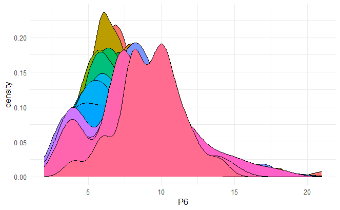

```r
p2<-df_patients_v20220321 %>%
  ggplot() +
  aes(x = P6, fill = DocID) +
  geom_density(adjust = 1L) +
  scale_fill_hue(direction = 1) +
  theme_minimal() +
  theme(legend.position = "none")
p2
```

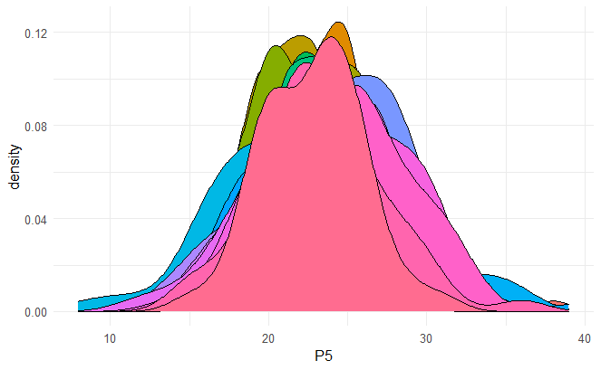

```r
p3<-df_patients_v20220321 %>%
  ggplot() +
  aes(x = P5, fill = DocID) +
  geom_density(adjust = 1L) +
  scale_fill_hue(direction = 1) +
  theme_minimal() +
  theme(legend.position = "none")
p3
```

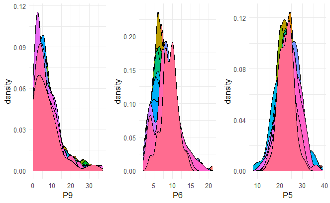

```r
multiplot(p1, p2, p3, cols=3)
```

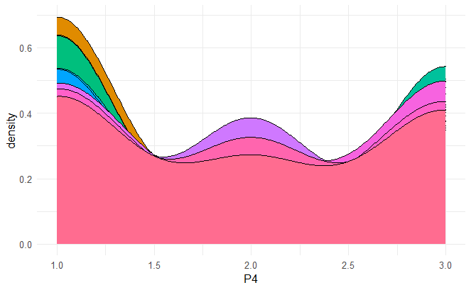

```r
df_patients_v20220321 %>%
  ggplot() +
  aes(x = P4, fill = DocID) +
  geom_density(adjust = 1L) +
  scale_fill_hue(direction = 1) +
  theme_minimal() +
  theme(legend.position = "none")
```

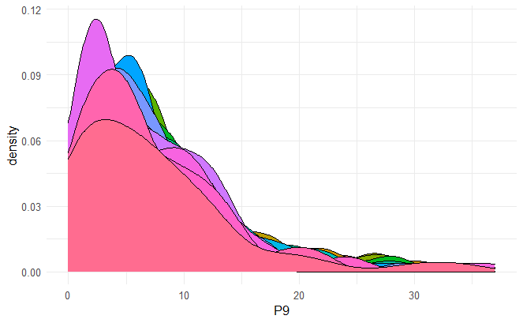

```r
df_patients_v20220321 %>%
  ggplot() +
  aes(x = P9, fill = DocID) +
  geom_density(adjust = 1L) +
  scale_fill_hue(direction = 1) +
  theme_minimal() +
  theme(legend.position = "none")
```

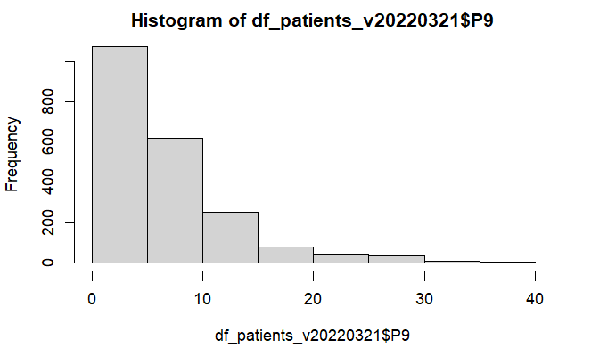

```r
hist(df_patients_v20220321$P9)
```

```r
fivenum(df_patients_v20220321$P9)# 50 percent of patient stayed at ICU  less than or equal to 5 days
```

```
[1]  0  2  5  9 37
```

## Performance measure from patient dataset

Here we are creating a performance measure based on P6, P8 and P9 variables and conditions from the above results.

```r
df_patients_v20220321<-df_patients_v20220321 %>%
  mutate(Performance=ifelse(P6>=6 & P8=="A" & P9<=5,1,0))

head(df_patients_v20220321)
```

| DocID | PtID | P1 | P2 | P3 | P4 | P5 | P6 | P7 | P8 | P9 | P10 | Performance |
| --- | --- | --- | --- | --- | --- | --- | --- | --- | --- | --- | --- | --- |
| doc-01 | 101103 | lt60 | no_op | medical | 1 | 27 | 11 | M | A | 10 | cardiovascular | 0 |
| doc-01 | 101108 | lt60 | no_op | medical | 3 | 22 | 5 | M | A | 6 | cardiovascular | 0 |
| doc-01 | 101151 | ge60 | no_op | medical | 3 | 22 | 5 | F | A | 10 | cardiovascular | 0 |
| doc-01 | 101551 | lt60 | no_op | medical | 3 | 21 | 6 | M | A | 8 | cardiovascular | 0 |
| doc-01 | 102061 | ge60 | no_op | medical | 2 | 24 | 6 | F | A | 6 | cardiovascular | 0 |
| doc-01 | 102327 | lt60 | no_op | trauma | 1 | 19 | 6 | M | A | 4 | cardiovascular | 1 |

```r
#View(df_patients_v20220321)
```

```r
# for performance measure 1

Performance_survey<-df_patients_v20220321 %>% group_by(DocID) %>% dplyr::summarize(Good=sum(Performance==1),Not_Good=sum(Performance==0))

Performance_survey
```

| DocID | Good | Not_Good |
| --- | --- | --- |
| doc-01 | 8 | 71 |
| doc-02 | 13 | 82 |
| doc-03 | 6 | 84 |
| doc-04 | 17 | 84 |
| doc-05 | 21 | 103 |
| doc-06 | 13 | 106 |
| doc-07 | 7 | 101 |
| doc-08 | 4 | 82 |
| doc-09 | 11 | 80 |
| doc-10 | 25 | 100 |

[output cut: 15 more lines]

```r
Percentage_performance<-Performance_survey %>%
  mutate(Percentage_Good=round(100*Performance_survey$Good/(Performance_survey$Good+Performance_survey$Not_Good),0))
Percentage_performance # based on patient dataframe
```

| DocID | Good | Not_Good | Percentage_Good |
| --- | --- | --- | --- |
| doc-01 | 8 | 71 | 10 |
| doc-02 | 13 | 82 | 14 |
| doc-03 | 6 | 84 | 7 |
| doc-04 | 17 | 84 | 17 |
| doc-05 | 21 | 103 | 17 |
| doc-06 | 13 | 106 | 11 |
| doc-07 | 7 | 101 | 6 |
| doc-08 | 4 | 82 | 5 |
| doc-09 | 11 | 80 | 12 |
| doc-10 | 25 | 100 | 20 |

[output cut: 15 more lines]

Which doctors (DocID) have performance greater than 40%, 38%, 35% and 30%?

```r
# for performance measure 2
which(Percentage_performance$Percentage_Good>=40)
```

```
[1] 24
```

```r
which(Percentage_performance$Percentage_Good>=38)
```

```
[1] 24
```

```r
which(Percentage_performance$Percentage_Good>=35)
```

```
[1] 21 24 25
```

```r
which(Percentage_performance$Percentage_Good>=30)
```

```
[1] 21 24 25
```

ICU stay <= 9 days (75% of patients)

```r
df_patients_v20220321<-df_patients_v20220321 %>%
  mutate(Performance_3=ifelse(P6>=6 & P8=="A" & P9<=9,1,0))

head(df_patients_v20220321)
```

| DocID | PtID | P1 | P2 | P3 | P4 | P5 | P6 | P7 | P8 | P9 | P10 | Performance | Performance_3 |
| --- | --- | --- | --- | --- | --- | --- | --- | --- | --- | --- | --- | --- | --- |
| doc-01 | 101103 | lt60 | no_op | medical | 1 | 27 | 11 | M | A | 10 | cardiovascular | 0 | 0 |
| doc-01 | 101108 | lt60 | no_op | medical | 3 | 22 | 5 | M | A | 6 | cardiovascular | 0 | 0 |
| doc-01 | 101151 | ge60 | no_op | medical | 3 | 22 | 5 | F | A | 10 | cardiovascular | 0 | 0 |
| doc-01 | 101551 | lt60 | no_op | medical | 3 | 21 | 6 | M | A | 8 | cardiovascular | 0 | 1 |
| doc-01 | 102061 | ge60 | no_op | medical | 2 | 24 | 6 | F | A | 6 | cardiovascular | 0 | 1 |
| doc-01 | 102327 | lt60 | no_op | trauma | 1 | 19 | 6 | M | A | 4 | cardiovascular | 1 | 1 |

```r
#View(df_patients_v20220321)
```

Let’s see the performance measure now.

```r
# for performance measure 1

Performance_survey<-df_patients_v20220321 %>% group_by(DocID) %>% dplyr::summarize(Good=sum(Performance_3==1),Not_Good=sum(Performance_3==0))

Performance_survey
```

| DocID | Good | Not_Good |
| --- | --- | --- |
| doc-01 | 11 | 68 |
| doc-02 | 15 | 80 |
| doc-03 | 8 | 82 |
| doc-04 | 22 | 79 |
| doc-05 | 30 | 94 |
| doc-06 | 19 | 100 |
| doc-07 | 19 | 89 |
| doc-08 | 9 | 77 |
| doc-09 | 17 | 74 |
| doc-10 | 39 | 86 |

[output cut: 15 more lines]

```r
Percentage_performance<-Performance_survey %>%
  mutate(Percentage_Good=round(100*Performance_survey$Good/(Performance_survey$Good+Performance_survey$Not_Good),0))
Percentage_performance # based on patient dataframe
```

| DocID | Good | Not_Good | Percentage_Good |
| --- | --- | --- | --- |
| doc-01 | 11 | 68 | 14 |
| doc-02 | 15 | 80 | 16 |
| doc-03 | 8 | 82 | 9 |
| doc-04 | 22 | 79 | 22 |
| doc-05 | 30 | 94 | 24 |
| doc-06 | 19 | 100 | 16 |
| doc-07 | 19 | 89 | 18 |
| doc-08 | 9 | 77 | 10 |
| doc-09 | 17 | 74 | 19 |
| doc-10 | 39 | 86 | 31 |

[output cut: 15 more lines]

Which doctors (DocID) have performance greater than or eauql to 45%, 40%, 38%, 35% and 30%?

```r
# for performance measure 2
which(Percentage_performance$Percentage_Good>=45)
```

```
[1] 21 24 25
```

```r
which(Percentage_performance$Percentage_Good>=40)
```

```
[1] 15 17 21 22 24 25
```

```r
which(Percentage_performance$Percentage_Good>=38)
```

```
[1] 15 17 19 21 22 24 25
```

```r
which(Percentage_performance$Percentage_Good>=35)
```

```
 [1] 15 17 18 19 20 21 22 23 24 25
```

```r
which(Percentage_performance$Percentage_Good>=30)
```

```
 [1] 10 13 14 15 17 18 19 20 21 22 23 24 25
```

# Extra analysis

This extra analysis helped us to understand the dataset and the variables correlations, physicians clusters and more.

Libraries used:

```r
library(tidyverse)  # data manipulation
library(cluster)    # clustering algorithms
library(factoextra) # clustering algorithms & visualization
```

Let’s see the doctors which have similar behaviour (measured with a distance matrix).

```r
distance <- get_dist(df_doctors_v20220321)
distance
```

```
            1          2          3          4          5          6
2  0.86211715
3  0.42785886 0.43425830
4  1.93403140 2.00381661 1.92121265
5  3.57654842 2.88555625 3.22332719 4.08265878
6  3.78403820 3.07158994 3.42186083 4.03559217 2.71889502
7  2.92332453 2.34103443 2.61509275 2.88349779 2.44833978 1.05490085
8  0.39704885 0.46506830 0.03081000 1.66186273 2.81299161 3.44743824
9  0.07311488 0.93523203 0.50097373 1.68498171 3.15104392 3.84727866
10 2.33045202 1.97078125 2.11599460 0.91504517 3.62606839 3.32858631
11 2.27536765 3.13748480 2.70322650 2.75963662 4.87716925 5.86078961
12 1.57739371 0.71527656 1.14953486 2.31766072 2.39791419 2.55158283
13 4.78710741 4.10526019 4.44088747 4.14470692 4.38089489 2.03327055
14 0.48724806 1.34936521 0.91510691 1.78381066 3.46115964 4.21151985
15 5.48796090 4.75717093 5.12017399 4.23655747 4.00668521 2.43829963
16 3.28819340 4.15031056 3.71605226 3.50064732 5.70983659 6.82605738
17 2.13059763 1.91621149 1.98067541 3.36589137 1.80699668 3.57213731
18 2.20629141 2.73872270 2.44715933 1.18438330 4.86932986 5.13228991
19 1.91731379 2.14166652 1.98550566 0.31936112 4.27676863 4.31610544
20 2.09223796 2.56405586 2.29825282 1.11476685 5.44022246 4.91931908
21 3.77181337 3.06051431 3.41011698 4.02508893 2.71766419 0.01418141
22 2.40855692 2.00631763 2.17577989 1.18930446 4.13516421 3.25321536
23 3.29089276 2.63788149 2.95343272 3.62162627 2.72981633 0.58734706
24 1.94247589 1.98837744 1.91753951 0.04739954 4.05520084 3.99518094
25 5.87901915 5.07169280 5.47626498 5.14415419 3.21400373 2.29465215
            7          8          9         10         11         12
2
3
4
5
6
7
8  2.28299245
9  2.57985122 0.40717373
10 2.46608776 1.84401735 2.05497940
11 4.22272082 2.31438058 1.90720684 3.53408150
12 2.01629465 1.18034486 1.65050859 1.93098991 3.85276136
13 2.58642510 4.46534585 4.84757577 3.24455857 6.78659711 3.59873894
14 2.86388512 0.76582359 0.35864985 2.28519563 1.54855699 2.06464177
15 2.77167371 4.45686804 4.80788874 3.41336963 6.53932520 4.18893097
```

[output cut: 45 more lines]

```
11
12
13
14
15
16
17
18
19
20 0.74600039
21 4.30507184 4.90748601
22 1.55807092 2.30407131 3.24537808
23 3.87630636 4.44076151 0.57316565 2.96827420
24 0.36676066 1.16949913 3.98476596 1.13457219 3.58551768
25 5.43034805 6.95074074 2.30883356 4.91145828 2.88199921 5.10201284
```

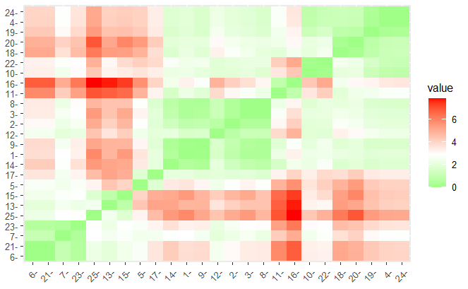

```r
fviz_dist(distance, gradient = list(low = "green", mid = "white", high = "red"))
```

## Hierarchial clustering for doctors dataset

```r
d <- dist(df_doctors_v20220321[,-10], method = "euclidean")
# Ward's method
hc4 <- hclust(d, method = "ward.D2" )

# Cut tree into 4 groups
sub_grp <- cutree(hc4, k = 3)

# Number of members in each cluster
table(sub_grp)
```

```
sub_grp
1 2 3
9 9 7
```

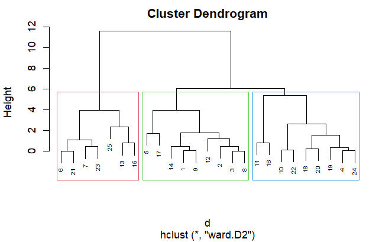

```r
plot(hc4, cex = 0.6)
rect.hclust(hc4, k = 3, border = 2:4)
```

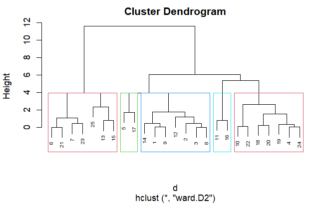

```r
plot(hc4, cex = 0.6)
rect.hclust(hc4, k = 5, border = 2:5)
```

```r
sub_grp <- cutree(hc4, k = 5)
table(sub_grp)
```

```
sub_grp
1 2 3 4 5
7 7 2 7 2
```

```r
sub_grp
```

```
 [1] 1 1 1 2 3 4 4 1 1 2 5 1 4 1 4 5 3 2 2 2 4 2 4 2 4
```

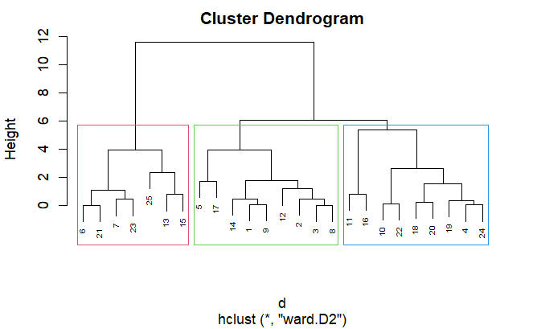

```r
plot(hc4, cex = 0.6)
rect.hclust(hc4, k = 3, border = 2:4)
```

```r
sub_grp <- cutree(hc4, k = 3)
table(sub_grp)
```

```
sub_grp
1 2 3
9 9 7
```

```r
sub_grp
```

```
 [1] 1 1 1 2 1 3 3 1 1 2 2 1 3 1 3 2 1 2 2 2 3 2 3 2 3
```

We observe three clear clusters in which the doctors may be organized. This is our second approach we will think of. three levels of physician performance classification (low-medium-High performance).

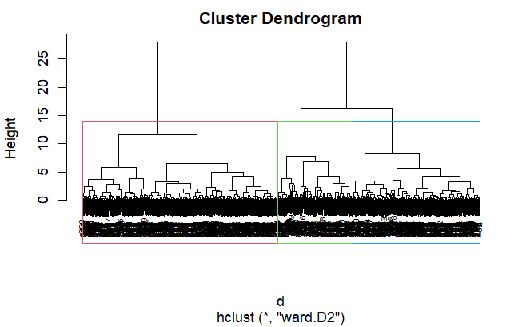

```r
d <- dist(df_eval360_v20220321[,c(23,26,28,29,30)], method = "euclidean")

# Ward's method
hc4 <- hclust(d, method = "ward.D2" )
plot(hc4, cex = 0.6)
rect.hclust(hc4, k = 3, border = 2:4)
```

```r
sub_grp <- cutree(hc4, k = 3)
table(sub_grp)
```

```
sub_grp
  1   2   3
152 392 256
```

```r
sub_grp
```

[output not shown]

# Correlation graphs

Correlation graphs based on P8 as a factor variable.

[output not shown]

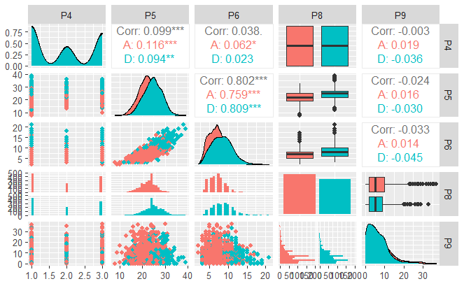

```r
library(GGally)
ggpairs(df_patients_v20220321[,c(6,7,8,10,11)], ggplot2::aes(colour=P8))
```

Correlation graphs based on P7 as a factor variable.

[output not shown]

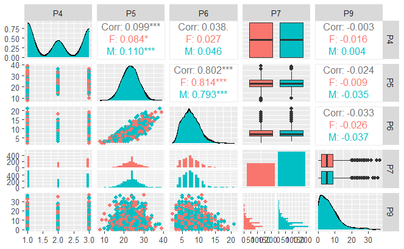

```r
ggpairs(df_patients_v20220321[,c(6,7,8,9,11)], ggplot2::aes(colour=P7))
```

Correlation graphs based on P1 as a factor variable.

[output not shown]

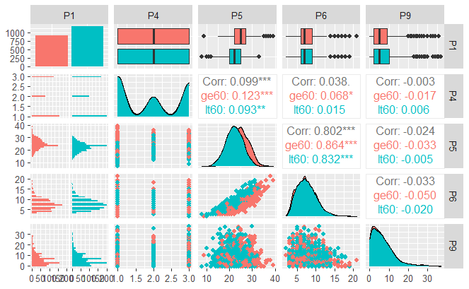

```r
ggpairs(df_patients_v20220321[,c(3,6,7,8,11)], ggplot2::aes(colour=P1))
```

### Spearman correlation betweeen Q1-Q23 questions

Correlation expresses the extent to which two variables are related to each other.Features with high correlation are more linearly dependent and hence have almost the same effect on the dependent variable. Therefore, when two features have high correlation, we can drop one of them.

```r
M=round(cor(na.omit(df_eval360_v20220321[,-c(24:32)]),method = "spearman"),2)# roudn to 2 decimal figures

M
```

```
       Q1    Q2    Q3    Q4    Q5    Q6    Q7    Q8    Q9   Q10   Q11   Q12   Q13
Q1   1.00  0.09 -0.16  0.26 -0.12  0.09 -0.11  0.15 -0.15 -0.15  0.16  0.07 -0.05
Q2   0.09  1.00 -0.05  0.02  0.05 -0.12 -0.02  0.10 -0.11 -0.08  0.08 -0.03  0.00
Q3  -0.16 -0.05  1.00 -0.19  0.07 -0.06  0.07  0.03  0.05  0.12 -0.03  0.07 -0.12
Q4   0.26  0.02 -0.19  1.00 -0.04  0.15 -0.02 -0.04 -0.03 -0.07  0.07  0.01 -0.03
Q5  -0.12  0.05  0.07 -0.04  1.00 -0.01  0.28 -0.05 -0.01 -0.05 -0.10 -0.08 -0.03
Q6   0.09 -0.12 -0.06  0.15 -0.01  1.00 -0.01 -0.05 -0.02  0.15  0.04  0.12  0.12
Q7  -0.11 -0.02  0.07 -0.02  0.28 -0.01  1.00  0.07  0.07 -0.04  0.05 -0.19 -0.03
Q8   0.15  0.10  0.03 -0.04 -0.05 -0.05  0.07  1.00 -0.03  0.06  0.08 -0.14  0.07
Q9  -0.15 -0.11  0.05 -0.03 -0.01 -0.02  0.07 -0.03  1.00 -0.19 -0.20 -0.09 -0.09
Q10 -0.15 -0.08  0.12 -0.07 -0.05  0.15 -0.04  0.06 -0.19  1.00  0.03  0.03 -0.05
Q11  0.16  0.08 -0.03  0.07 -0.10  0.04  0.05  0.08 -0.20  0.03  1.00 -0.01 -0.08
Q12  0.07 -0.03  0.07  0.01 -0.08  0.12 -0.19 -0.14 -0.09  0.03 -0.01  1.00 -0.04
Q13 -0.05  0.00 -0.12 -0.03 -0.03  0.12 -0.03  0.07 -0.09 -0.05 -0.08 -0.04  1.00
Q14  0.27 -0.01  0.13  0.01 -0.10 -0.04  0.11  0.00 -0.09 -0.02  0.11 -0.08  0.25
Q15 -0.05 -0.17 -0.02  0.12 -0.10  0.07 -0.04 -0.12  0.13  0.06  0.21  0.02  0.04
Q16 -0.01  0.15  0.26  0.02  0.06 -0.06  0.03  0.11 -0.24  0.14  0.06  0.13 -0.18
Q17  0.25  0.11  0.04  0.10  0.13 -0.17 -0.07  0.06  0.16 -0.18 -0.10  0.00 -0.03
Q18  0.03  0.07 -0.06  0.08 -0.08  0.05 -0.09 -0.05 -0.10  0.05 -0.15 -0.07 -0.09
Q19  0.07  0.18  0.12 -0.07  0.03  0.05  0.05 -0.02  0.05 -0.04  0.09 -0.11  0.04
Q20 -0.04 -0.05  0.04  0.00  0.00 -0.11  0.08  0.23 -0.15  0.01 -0.06 -0.16  0.04
Q21  0.10 -0.09  0.03 -0.02  0.03  0.16 -0.08 -0.17  0.01  0.00 -0.19 -0.05  0.02
Q22  0.14  0.03 -0.01 -0.05  0.09 -0.36 -0.04  0.01  0.10  0.03  0.08 -0.01 -0.15
Q23 -0.10  0.04  0.15  0.03  0.13 -0.01  0.07 -0.15 -0.02  0.03  0.11 -0.33 -0.03
      Q14   Q15   Q16   Q17   Q18   Q19   Q20   Q21   Q22   Q23
Q1   0.27 -0.05 -0.01  0.25  0.03  0.07 -0.04  0.10  0.14 -0.10
Q2  -0.01 -0.17  0.15  0.11  0.07  0.18 -0.05 -0.09  0.03  0.04
Q3   0.13 -0.02  0.26  0.04 -0.06  0.12  0.04  0.03 -0.01  0.15
Q4   0.01  0.12  0.02  0.10  0.08 -0.07  0.00 -0.02 -0.05  0.03
Q5  -0.10 -0.10  0.06  0.13 -0.08  0.03  0.00  0.03  0.09  0.13
Q6  -0.04  0.07 -0.06 -0.17  0.05  0.05 -0.11  0.16 -0.36 -0.01
Q7   0.11 -0.04  0.03 -0.07 -0.09  0.05  0.08 -0.08 -0.04  0.07
Q8   0.00 -0.12  0.11  0.06 -0.05 -0.02  0.23 -0.17  0.01 -0.15
Q9  -0.09  0.13 -0.24  0.16 -0.10  0.05 -0.15  0.01  0.10 -0.02
Q10 -0.02  0.06  0.14 -0.18  0.05 -0.04  0.01  0.00  0.03  0.03
Q11  0.11  0.21  0.06 -0.10 -0.15  0.09 -0.06 -0.19  0.08  0.11
Q12 -0.08  0.02  0.13  0.00 -0.07 -0.11 -0.16 -0.05 -0.01 -0.33
Q13  0.25  0.04 -0.18 -0.03 -0.09  0.04  0.04  0.02 -0.15 -0.03
Q14  1.00 -0.07 -0.04  0.09 -0.08  0.18  0.08 -0.03  0.00  0.29
Q15 -0.07  1.00 -0.05 -0.05 -0.02  0.07 -0.10 -0.01 -0.01 -0.01
Q16 -0.04 -0.05  1.00 -0.05 -0.08 -0.01  0.02 -0.12  0.12  0.02
Q17  0.09 -0.05 -0.05  1.00 -0.01  0.00 -0.13 -0.06  0.11 -0.08
Q18 -0.08 -0.02 -0.08 -0.01  1.00  0.20  0.15 -0.02  0.01 -0.12
Q19  0.18  0.07 -0.01  0.00  0.20  1.00  0.09 -0.04 -0.09  0.30
Q20  0.08 -0.10  0.02 -0.13  0.15  0.09  1.00  0.02  0.05 -0.06
Q21 -0.03 -0.01 -0.12 -0.06 -0.02 -0.04  0.02  1.00 -0.06  0.18
Q22  0.00 -0.01  0.12  0.11  0.01 -0.09  0.05 -0.06  1.00  0.03
Q23  0.29 -0.01  0.02 -0.08 -0.12  0.30 -0.06  0.18  0.03  1.00
```

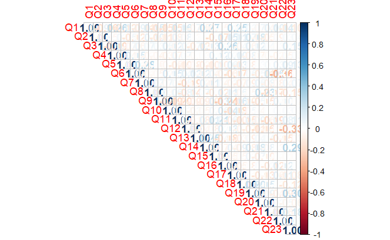

```r
corrplot(cor(na.omit(df_eval360_v20220321[,-c(24:32)]),method = "spearman"), method = "number",type = "upper") # show only upper side
```

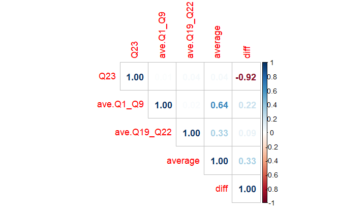

```r
M=round(cor(na.omit(df_eval360_v20220321[,c(23,26,28:30)]),method = "spearman"),2)# roudn to 2 decimal figures

corrplot(cor(na.omit(df_eval360_v20220321[,c(23,26,28:30)]),method = "spearman"), method = "number",type = "upper") # show only upper side
```

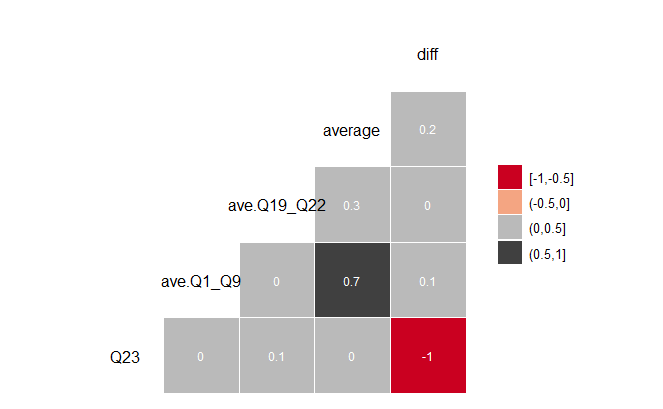

```r
library(GGally)
g1<-ggcorr(na.omit(df_eval360_v20220321[,c(23,26,28:30)]), nbreaks = 4, palette = "RdGy", label = TRUE, label_size = 3, label_color = "white")
g1
```

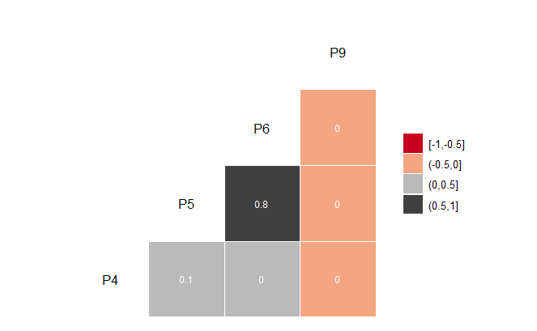

```r
g2<-ggcorr(na.omit(df_patients_v20220321[,c(6:8,11)]), nbreaks = 4, palette = "RdGy", label = TRUE, label_size = 3, label_color = "white")
g2
```

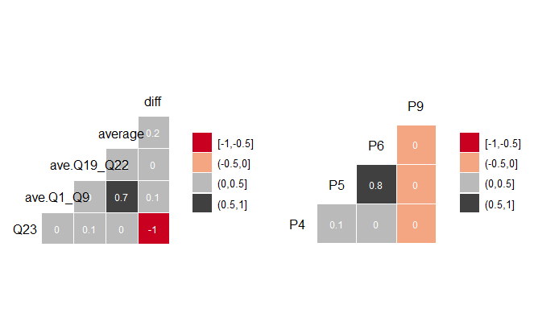

```r
multiplot(g1,g2,cols=2)
```